# Statistical analysis report for ‘Multi-kingdom microbial assemblage modulates its metabolism under contrasted cloud conditions’.

Domitille Jarrige

2025-08-25

```r
setwd("C:/Users/djarrige/Desktop/Domitille/projets/Anciens_projets/METACLOUD/scripts/")
```

# Variables

```r
vect_COG_category_long <- c("A" = "A: RNA processing and modification",
                            "B" = "B: Chromatin Structure and dynamics",
                            "C" = "C: Energy production and conversion",
                            "D" = "D: Cell cycle control, cell division, chromosome partitioning",
                            "E" = "E: Amino Acid transport and metabolism",
                            "F" = "F: Nucleotide transport and metabolism",
                            "G" = "G: Carbohydrate transport and metabolism",
                            "H" = "H: Coenzyme transport and metabolism",
                            "I" = "I: Lipid transport and metabolism",
                            "J" = "J: Translation, ribosomal structure and biogenesis",
                            "K" = "K: Transcription",
                            "L" = "L: Replication, recombination and repair",
                            "M" = "M: Cell wall/membrane/envelope biogenesis",
                            "N" = "N: Cell motility",
                            "O" = "O: Post-translational modification, protein turnover, chaperones",
                            "P" = "P: Inorganic ion transport and metabolism",
                            "Q" = "Q: Secondary metabolites biosynthesis, transport and catabolism",
                            "T" = "T: Signal Transduction mechanisms",
                            "U" = "U: Intracellular trafficking, secretion and vesicular transport",
                            "V" = "V: Defense mechanisms",
                            "W" = "W: Extracellular structures",
                            "X" = "X: Mobilome: prophages, transposons",
                            "Y" = "Y: Nuclear structure",
                            "Z" = "Z: Cytoskeleton",
                            "R" = "R: General functional prediction only",
                            "S" = "S: Function unknown" #,
                            # "-" = "-: Other"
                            )


COG_colours <- hue_pal()(length(vect_COG_category_long))
names(COG_colours) <- vect_COG_category_long

species_colours <- c("D.hungarica" = "#e66101", "P.graminis" = "#fdb863",
                     "P.syringae" = "#b2abd2", "R.enclensis" = "#5e3c99")
```

# Functions

```r
compute_deseq2_analysis = function(myData, sample_data, subset_var=FALSE, select=FALSE,
                                   contrast_col, ref, tested){
  data <- myData
  sample <- sample_data
  if ((subset_var != FALSE) & (select != FALSE)){
    sample %>% filter(!!as.name(subset_var) == select) -> sample
  }

  sample[[contrast_col]] <- factor(sample[[contrast_col]])
  data <- data[row.names(sample)]

  data_matrix <- round(as.matrix(data))
  d = formula(paste("~", " ", contrast_col))

  dds <- DESeqDataSetFromMatrix(countData = data_matrix,
                                colData = sample,
                                design = d)
  dds <- estimateSizeFactors(dds)
  dds <- DESeq(dds)
  resultsNames(dds)
  resDESeq <- results(dds, contrast = c(contrast_col, tested, ref),
                      independentFiltering = TRUE, alpha=0.1)

  resDESeq <- resDESeq[order(resDESeq$padj),]
  res <- data.frame(resDESeq)
  res$gene = row.names(res)
  res$condition = select
  res$SAMPLE_COMPARISON = paste0(tested, "_VS_", ref)

  return(res)
}
```

# Experimental setup

Comparison of an artificial microbial assemblage gene expression under two cloud-like conditions:

- **summer day (SD):** light, 250µM H2O2, 17°C
- **winter night (WN):** dark, no added H2O2, 5°C

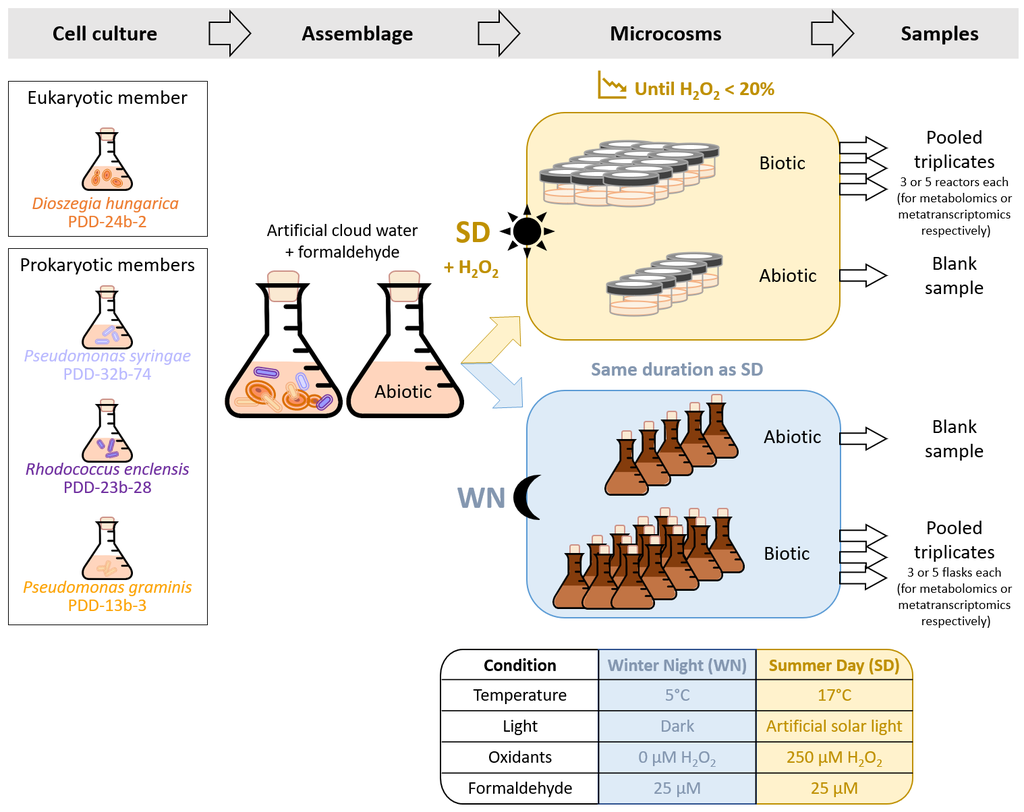

# Bioinformatic workflow and mapping overview

The metatranscriptomics data was processed using a custom made Snakemake workflow.

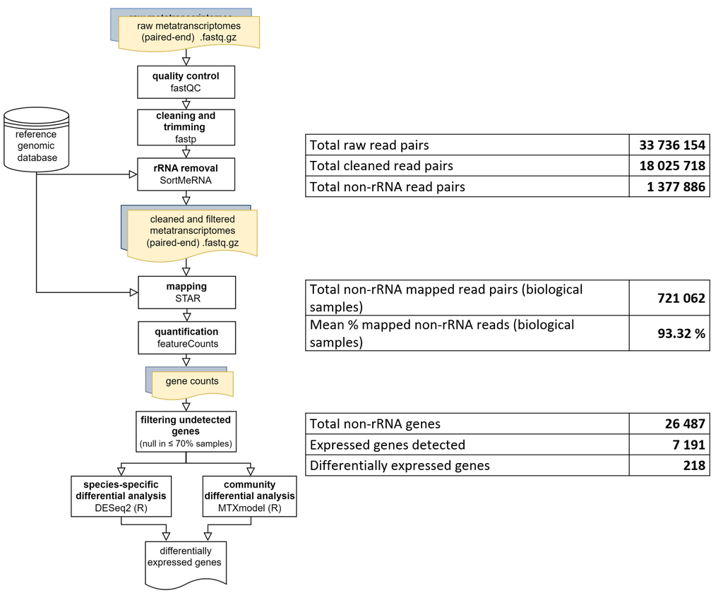

Two sequencing runs were performed by Genoscreen (Lille, France) as the first run produced relatively low quality reads. Both runs are added into a single dataset in our analyses.

After quality control steps and read cleaning ([report](https://seafile.unistra.fr/f/61e1c9bd97f049a2a4f4/?dl=1)) remaining rRNA (not depleted prior to sequencing) were removed with sortmeRNA. As fungal rRNA were not depleted in our libraries, the vast majority of our reads correspond to *Dioszegia* *hungarica* rRNAs.

Non ribosomal and ribosomal RNAs were then mapped separately on our reference genomes using STAR.

For non rRNA reads: **~90-95% of reads mapped in biological samples**. In blank samples, around 40% of reads were mapped, and only partially.

Few reads were mapped on *P. graminis* PDD-13b-3 genome. It will be difficult to get significant results for this species.

Lastly, for each gene of the assemblage, read counts were obtained with featureCounts.’-M’ and ‘–fraction’ options were used to count multi-mapping reads fractionally (if a read maps on x features: each feature gets 1/x counts).

# Analyses

##### Load counts and annotation data

```r
counts_table <- read.csv("../results/all_counts_community_artificial_no_rRNA.tsv", sep = "\t", row.names = "Geneid")

metadata_table <- read.csv("../data/metadata.txt", sep = "\t", row.names = "name") # row.names = "sample"


counts_table %>% rename("WN_TF_1" = "S_5C1",
                        "WN_TF_2" = "S_5C2",
                        "WN_TF_3" = "S_5C3",
                        "WN_BLK" = "S_5BLK",
                        "SD_TF_1" = "S_17C1",
                        "SD_TF_2" = "S_17C2",
                        "SD_TF_3" = "S_17C3",
                        "SD_BLK" = "S_17BLK") -> counts_table

annotation_table <- read.csv("../data/annotations_final_community_updated.tsv", sep="\t", row.names = "Geneid")
annotation_all <- read.csv("../data/annotations_final_community_updated.tsv", sep="\t", row.names = "Geneid")
annotation_table_long <- read.csv("../data/annotations_final_community_long2.tsv", sep="\t", row.names = "Geneid")

## added july 2024
counts_table <- counts_table[intersect(rownames(counts_table), rownames(annotation_all)),]



annotation_diohu <- read.csv("../data/dioszegia_kegg.tsv", sep="\t", row.names = "Geneid")
annotation_psegr <- read.csv("../data/pseudomonas_graminis_kegg.tsv", sep="\t", row.names = "Geneid")
annotation_psesy <- read.csv("../data/pseudomonas_syringae_kegg.tsv", sep="\t", row.names = "Geneid")
annotation_rhoen <- read.csv("../data/rhodococcus_kegg.tsv", sep="\t", row.names = "Geneid")

chem_data_metaT <- read.csv("../data/formaldehyde_evolution_transcriptomics.txt", sep="\t")
chem_data_metaB <- read.csv("../data/formaldehyde_evolution_metabolomics.txt", sep="\t")

## Data for figure

annotation_table_fig <- readxl::read_excel("../data/Table_S3_DEGs_annotations.xlsx")
rename(annotation_table_fig, "COG_category" = "COG category",
       "COG_category_long" = "COG category long",
       "COG_process" = "COG process") -> annotation_table_fig

metabolomics_df <- read.csv("../data/metabolomics.txt", sep="\t", row.names = 1)

# keep a version of the metabolomics dataset with all time points
metabolomics_df -> metabolomics_all_times_df
metabolomics_all_times_df %>% t() %>% data.frame() -> metabolomics_all_times_df

metabolomics_all_times_df %>% rename("WN_T0_1" = "S5C_T0_1",
                                     "WN_T0_2" = "S5C_T0_2",
                                     "WN_T0_3" = "S5C_T0_3",
                                     "SD_T0_1" = "S17C_T0_1",
                                     "SD_T0_2" = "S17C_T0_2",
                                     "SD_T0_3" = "S17C_T0_3",
                                     "WN_TF_1" = "S5C_TF_1",
                                     "WN_TF_2" = "S5C_TF_2",
                                     "WN_TF_3" = "S5C_TF_3",
                                     "SD_TF_1" = "S17C_TF_1",
                                     "SD_TF_2" = "S17C_TF_2",
                                     "SD_TF_3" = "S17C_TF_3") -> metabolomics_all_times_df

metabolomics_all_times_df <- metabolomics_all_times_df[,c("WN_T0_1", "WN_T0_2", "WN_T0_3", "SD_T0_1", "SD_T0_2", "SD_T0_3",
                                                          "WN_TF_1", "WN_TF_2", "WN_TF_3", "SD_TF_1", "SD_TF_2", "SD_TF_3")]

metadata_table_metaB_all_times <- read.csv("../data/metadata_metaB.txt", sep = "\t", row.names = "name") # row.names = "sample"

# Keep final time points only, like for metatranscriptomics
metabolomics_df  %>% t() %>%
  data.frame() %>% select(starts_with(c("S17C_TF_", "S5C_TF_"))) -> metabolomics_df


metabolomics_df %>% rename("WN_TF_1" = "S5C_TF_1",
                           "WN_TF_2" = "S5C_TF_2",
                           "WN_TF_3" = "S5C_TF_3",
                           "SD_TF_1" = "S17C_TF_1",
                           "SD_TF_2" = "S17C_TF_2",
                           "SD_TF_3" = "S17C_TF_3") -> metabolomics_df

metabolomics_box_plot_df <- readxl::read_excel("../results/metabolomics_annotation_boxplot.xlsx")

metabolomics_annotations <- readxl::read_excel("../results/Table_S2_Metabolites_identified.xlsx", n_max = 25)
```

##### Removal of blank samples

```r
counts_table <- counts_table[,c("WN_TF_1", "WN_TF_2", "WN_TF_3", "SD_TF_1", "SD_TF_2", "SD_TF_3")]
metadata_table <- metadata_table[c("WN_TF_1", "WN_TF_2", "WN_TF_3", "SD_TF_1", "SD_TF_2", "SD_TF_3"),]
```

## Chemical properties of the samples

### Formaldehyde evolution

```r
chem_data_metaT$experiment <- "metaT"
chem_data_metaB$experiment <- "metaB"

chem_data <- rbind(chem_data_metaT, chem_data_metaB)



## Metatranscriptomics data

chem_data[chem_data$color == "#89DDF8" & chem_data$experiment == "metaT",] -> tmp1
group_by(tmp1, sampling_time) %>% summarise(formaldehyde_mean=mean(formaldehyde_ratio_to_initial),
                                            formaldehyde_sd=sd(formaldehyde_ratio_to_initial)) -> tmp1
tmp1$color <- "#89DDF8"
tmp1$condition <- "WN"
tmp1$category <- "biotic_WN"
tmp1$experiment <- "metaT"

chem_data[chem_data$color == "#F8AD18" & chem_data$experiment == "metaT",] -> tmp2
group_by(tmp2, sampling_time) %>% summarise(formaldehyde_mean=mean(formaldehyde_ratio_to_initial),
                                            formaldehyde_sd=sd(formaldehyde_ratio_to_initial)) -> tmp2
tmp2$color <- "#F8AD18"
tmp2$condition <- "SD"
tmp2$category <- "biotic_SD"
tmp2$experiment <- "metaT"

chem_data[chem_data$color == "#A6C1CA" & chem_data$experiment == "metaT",] -> tmp3
group_by(tmp3, sampling_time) %>% summarise(formaldehyde_mean=mean(formaldehyde_ratio_to_initial),
                                            formaldehyde_sd=sd(formaldehyde_ratio_to_initial)) -> tmp3
tmp3$color <- "#A6C1CA"
tmp3$condition <- "WN"
tmp3$category <- "abiotic_WN"
tmp3$experiment <- "metaT"

chem_data[chem_data$color == "#C4B69B" & chem_data$experiment == "metaT",] -> tmp4
group_by(tmp4, sampling_time) %>% summarise(formaldehyde_mean=mean(formaldehyde_ratio_to_initial),
                                            formaldehyde_sd=sd(formaldehyde_ratio_to_initial)) -> tmp4
tmp4$color <- "#C4B69B"
tmp4$condition <- "SD"
tmp4$category <- "abiotic_SD"
tmp4$experiment <- "metaT"

## Metabolomics data

chem_data[chem_data$color == "#89DDF8" & chem_data$experiment == "metaB",] -> tmp5
group_by(tmp5, sampling_time) %>% summarise(formaldehyde_mean=mean(formaldehyde_ratio_to_initial),
                                            formaldehyde_sd=sd(formaldehyde_ratio_to_initial)) -> tmp5
tmp5$color <- "#89DDF8"
tmp5$condition <- "WN"
tmp5$category <- "biotic_WN"
tmp5$experiment <- "metaB"

chem_data[chem_data$color == "#F8AD18" & chem_data$experiment == "metaB",] -> tmp6
group_by(tmp6, sampling_time) %>% summarise(formaldehyde_mean=mean(formaldehyde_ratio_to_initial),
                                            formaldehyde_sd=sd(formaldehyde_ratio_to_initial)) -> tmp6
tmp6$color <- "#F8AD18"
tmp6$condition <- "SD"
tmp6$category <- "biotic_SD"
tmp6$experiment <- "metaB"

chem_data[chem_data$color == "#A6C1CA" & chem_data$experiment == "metaB",] -> tmp7
group_by(tmp7, sampling_time) %>% summarise(formaldehyde_mean=mean(formaldehyde_ratio_to_initial),
                                            formaldehyde_sd=sd(formaldehyde_ratio_to_initial)) -> tmp7
tmp7$color <- "#A6C1CA"
tmp7$condition <- "WN"
tmp7$category <- "abiotic_WN"
tmp7$experiment <- "metaB"

chem_data[chem_data$color == "#C4B69B" & chem_data$experiment == "metaB",] -> tmp8
group_by(tmp8, sampling_time) %>% summarise(formaldehyde_mean=mean(formaldehyde_ratio_to_initial),
                                            formaldehyde_sd=sd(formaldehyde_ratio_to_initial)) -> tmp8
tmp8$color <- "#C4B69B"
tmp8$condition <- "SD"
tmp8$category <- "abiotic_SD"
tmp8$experiment <- "metaB"


## Merge data

line_data <- rbind(tmp1, tmp2, tmp3, tmp4, tmp5, tmp6, tmp7, tmp8)
rm(tmp1, tmp2, tmp3, tmp4, tmp5, tmp6, tmp7, tmp8)


## Test difference between biotic and abiotic


kruskal_formaldehyde <- c("",
                          try(if(kruskal.test(x = c(chem_data_metaB[(chem_data_metaB$sampling_time == 1 &
                                                                     chem_data_metaB$color == "#F8AD18"),
                                                                    "formaldehyde_ratio_to_initial"],
                                                    chem_data_metaB[(chem_data_metaB$sampling_time == 1 &
                                                                     chem_data_metaB$color == "#C4B69B"),
                                                                    "formaldehyde_ratio_to_initial"]),
                                              g = c(rep("biotic_SD", 3), rep("abiotic_SD", 3))
                          )[["p.value"]] < 0.05){"*"}else{""}, silent = TRUE) ,
                          try(if(kruskal.test(x = c(chem_data_metaB[(chem_data_metaB$sampling_time == 2 &
                                                                     chem_data_metaB$color == "#F8AD18"),
                                                                    "formaldehyde_ratio_to_initial"],
                                                    chem_data_metaB[(chem_data_metaB$sampling_time == 2 &
                                                                     chem_data_metaB$color == "#C4B69B"),
                                                                    "formaldehyde_ratio_to_initial"]),
                                              g = c(rep("biotic_SD", 3), rep("abiotic_SD", 3))
                          )[["p.value"]] < 0.05){"*"}else{""}, silent = TRUE),
                          try(if(kruskal.test(x = c(chem_data_metaB[(chem_data_metaB$sampling_time == 3 &
                                                                     chem_data_metaB$color == "#F8AD18"),
                                                                    "formaldehyde_ratio_to_initial"],
                                                    chem_data_metaB[(chem_data_metaB$sampling_time == 3 &
                                                                     chem_data_metaB$color == "#C4B69B"),
                                                                    "formaldehyde_ratio_to_initial"]),
                                              g = c(rep("biotic_SD", 3), rep("abiotic_SD", 3))
                          )[["p.value"]] < 0.05){"*"}else{""}, silent = TRUE),
                          "",
                          try(if(kruskal.test(x = c(chem_data_metaT[(chem_data_metaT$sampling_time == 1 &
                                                                     chem_data_metaT$color == "#F8AD18"),
                                                                    "formaldehyde_ratio_to_initial"],
                                                    chem_data_metaT[(chem_data_metaT$sampling_time == 1 &
                                                                     chem_data_metaT$color == "#C4B69B"),
                                                                    "formaldehyde_ratio_to_initial"]),
                                              g = c(rep("biotic_SD", 3), rep("abiotic_SD", 3))
                          )[["p.value"]] < 0.05){"*"}else{""}, silent = TRUE) ,
                          try(if(kruskal.test(x = c(chem_data_metaT[(chem_data_metaT$sampling_time == 2 &
                                                                     chem_data_metaT$color == "#F8AD18"),
                                                                    "formaldehyde_ratio_to_initial"],
                                                    chem_data_metaT[(chem_data_metaT$sampling_time == 2 &
                                                                     chem_data_metaT$color == "#C4B69B"),
                                                                    "formaldehyde_ratio_to_initial"]),
                                              g = c(rep("biotic_SD", 3), rep("abiotic_SD", 3))
                          )[["p.value"]] < 0.05){"*"}else{""}, silent = TRUE),
                          try(if(kruskal.test(x = c(chem_data_metaT[(chem_data_metaT$sampling_time == 3 &
                                                                     chem_data_metaT$color == "#F8AD18"),
                                                                    "formaldehyde_ratio_to_initial"],
                                                    chem_data_metaT[(chem_data_metaT$sampling_time == 3 &
                                                                     chem_data_metaT$color == "#C4B69B"),
                                                                    "formaldehyde_ratio_to_initial"]),
                                              g = c(rep("biotic_SD", 3), rep("abiotic_SD", 3))
                          )[["p.value"]] < 0.05){"*"}else{""}, silent = TRUE),
                          try(if(kruskal.test(x = c(chem_data_metaT[(chem_data_metaT$sampling_time == 5 &
                                                                     chem_data_metaT$color == "#F8AD18"),
                                                                    "formaldehyde_ratio_to_initial"],
                                                    chem_data_metaT[(chem_data_metaT$sampling_time == 5 &
                                                                     chem_data_metaT$color == "#C4B69B"),
                                                                    "formaldehyde_ratio_to_initial"]),
                                              g = c(rep("biotic_SD", 3), rep("abiotic_SD", 3))
                          )[["p.value"]] < 0.05){"*"}else{""}, silent = TRUE),
                          "",
                          try(if(kruskal.test(x = c(chem_data_metaB[(chem_data_metaB$sampling_time == 1 &
                                                                     chem_data_metaB$color == "#89DDF8"),
                                                                    "formaldehyde_ratio_to_initial"],
                                                    chem_data_metaB[(chem_data_metaB$sampling_time == 1 &
                                                                     chem_data_metaB$color == "#A6C1CA"),
                                                                    "formaldehyde_ratio_to_initial"]),
                                              g = c(rep("biotic_WN", 3), rep("abiotic_WN", 3))
                          )[["p.value"]] < 0.05){"*"}else{""}, silent = TRUE) ,
                          try(if(kruskal.test(x = c(chem_data_metaB[(chem_data_metaB$sampling_time == 2 &
                                                                     chem_data_metaB$color == "#89DDF8"),
                                                                    "formaldehyde_ratio_to_initial"],
                                                    chem_data_metaB[(chem_data_metaB$sampling_time == 2 &
                                                                     chem_data_metaB$color == "#A6C1CA"),
                                                                    "formaldehyde_ratio_to_initial"]),
                                              g = c(rep("biotic_WN", 3), rep("abiotic_WN", 3))
                          )[["p.value"]] < 0.05){"*"}else{""}, silent = TRUE),
                          try(if(kruskal.test(x = c(chem_data_metaB[(chem_data_metaB$sampling_time == 3 &
                                                                     chem_data_metaB$color == "#89DDF8"),
                                                                    "formaldehyde_ratio_to_initial"],
                                                    chem_data_metaB[(chem_data_metaB$sampling_time == 3 &
                                                                     chem_data_metaB$color == "#A6C1CA"),
                                                                    "formaldehyde_ratio_to_initial"]),
                                              g = c(rep("biotic_WN", 3), rep("abiotic_WN", 3))
                          )[["p.value"]] < 0.05){"*"}else{""}, silent = TRUE),
                          "",
                          try(if(kruskal.test(x = c(chem_data_metaT[(chem_data_metaT$sampling_time == 1 &
                                                                     chem_data_metaT$color == "#89DDF8"),
                                                                    "formaldehyde_ratio_to_initial"],
                                                    chem_data_metaT[(chem_data_metaT$sampling_time == 1 &
```

```r
                                                                     chem_data_metaT$color == "#A6C1CA"),
                                                                    "formaldehyde_ratio_to_initial"]),
                                              g = c(rep("biotic_WN", 3), rep("abiotic_WN", 3))
                          )[["p.value"]] < 0.05){"*"}else{""}, silent = TRUE) ,
                          try(if(kruskal.test(x = c(chem_data_metaT[(chem_data_metaT$sampling_time == 2 &
                                                                     chem_data_metaT$color == "#89DDF8"),
                                                                    "formaldehyde_ratio_to_initial"],
                                                    chem_data_metaT[(chem_data_metaT$sampling_time == 2 &
                                                                     chem_data_metaT$color == "#A6C1CA"),
                                                                    "formaldehyde_ratio_to_initial"]),
                                              g = c(rep("biotic_WN", 3), rep("abiotic_WN", 3))
                          )[["p.value"]] < 0.05){"*"}else{""}, silent = TRUE),
                          try(if(kruskal.test(x = c(chem_data_metaT[(chem_data_metaT$sampling_time == 3 &
                                                                     chem_data_metaT$color == "#89DDF8"),
                                                                    "formaldehyde_ratio_to_initial"],
                                                    chem_data_metaT[(chem_data_metaT$sampling_time == 3 &
                                                                     chem_data_metaT$color == "#A6C1CA"),
                                                                    "formaldehyde_ratio_to_initial"]),
                                              g = c(rep("biotic_WN", 3), rep("abiotic_WN", 3))
                          )[["p.value"]] < 0.05){"*"}else{""}, silent = TRUE),
                          try(if(kruskal.test(x = c(chem_data_metaT[(chem_data_metaT$sampling_time == 5 &
                                                                     chem_data_metaT$color == "#89DDF8"),
                                                                    "formaldehyde_ratio_to_initial"],
                                                    chem_data_metaT[(chem_data_metaT$sampling_time == 5 &
                                                                     chem_data_metaT$color == "#A6C1CA"),
                                                                    "formaldehyde_ratio_to_initial"]),
                                              g = c(rep("biotic_WN", 3), rep("abiotic_WN", 3))
                          )[["p.value"]] < 0.05){"*"}else{""}, silent = TRUE)
)

## Test difference between time 0 an the other time points

kruskal_df <- data.frame(time = rep(c(0, 1, 2, 3, 0, 1, 2, 3, 5), 2),
                         height = rep(0, 18),
                         experiment = rep(c(rep("metaB", 4), rep("metaT", 5)), 2),
                         condition = c(rep("SD", 9), rep("WN", 9)),
                         category = c(rep("community SD", 9), rep("community WN", 9)),
                         color = c(rep("#F8AD18", 9), rep("#89DDF8", 9)),
                         pvalue = kruskal_formaldehyde)


krusk <- kruskal_df


## Segment data for sampling time

segment_data <- data.frame(x = c(4, 0, 3.5), xend = c(4, 0, 3.5),
                           y = c(-Inf, -Inf, -Inf), yend = c(Inf, Inf, Inf),
                           experiment = c("metaT", "metaB", "metaB"))

chem_data %>% ggplot() +
  geom_point(aes(x=sampling_time, y=formaldehyde_ratio_to_initial, color=color)) +
  ylim(c(-0.1, 1.2)) +
  xlim(c(0, 5)) +
  scale_colour_identity("Category", labels = c("Assemblage Winter Night", "Abiotic Winter Night",
                                               "Abiotic Summer Day", "Assemblage Summer Day"),
                        guide="legend") +
  scale_fill_identity() +
  ylab(label = "Relative formaldehyde evolution") +
  xlab(label = "Incubation time (h)") +
  facet_grid(rows = vars(condition), cols = vars(experiment),
             labeller = as_labeller(c("metaT" = "Metatranscriptomics",
                                      "metaB" = "Meta-metabolomics",
                                      "SD" = "Summer Day",
                                      "WN" = "Winter Night"))) +
  theme(legend.position = "bottom",
        panel.background = element_rect(fill="#f4f4f4"),
        strip.text = element_text(size=12)) +


  geom_path(data = line_data[line_data$category == "biotic_SD",],
            aes(x = sampling_time, y = formaldehyde_mean, color = color),
            linewidth = 1) +
  geom_ribbon(data = line_data[line_data$category == "biotic_SD",],
              aes(x = sampling_time,
                  ymin = formaldehyde_mean - formaldehyde_sd,
                  ymax = formaldehyde_mean + formaldehyde_sd,
                  fill = color), alpha=0.25, linewidth=0.05) +

  geom_path(data = line_data[line_data$category == "abiotic_SD",],
            aes(x = sampling_time, y = formaldehyde_mean, color = color),
            linewidth = 1) +
  geom_ribbon(data = line_data[line_data$category == "abiotic_SD",],
              aes(x = sampling_time,
                  ymin = formaldehyde_mean - formaldehyde_sd,
                  ymax = formaldehyde_mean + formaldehyde_sd,
                  fill = color), alpha=0.25, linewidth=0.05) +

  geom_path(data = line_data[line_data$category == "biotic_WN",],
            aes(x = sampling_time, y = formaldehyde_mean, color = color),
            linewidth = 1) +
  geom_ribbon(data = line_data[line_data$category == "biotic_WN",],
              aes(x = sampling_time,
                  ymin = formaldehyde_mean - formaldehyde_sd,
                  ymax = formaldehyde_mean + formaldehyde_sd,
                  fill = color), alpha=0.25, linewidth=0.05) +

  geom_path(data = line_data[line_data$category == "abiotic_WN",],
            aes(x = sampling_time, y = formaldehyde_mean, color = color),
            linewidth = 1) +
  geom_ribbon(data = line_data[line_data$category == "abiotic_WN",],
              aes(x = sampling_time,
                  ymin = formaldehyde_mean - formaldehyde_sd,
                  ymax = formaldehyde_mean + formaldehyde_sd,
                  fill = color), alpha=0.25, linewidth=0.05) +
```

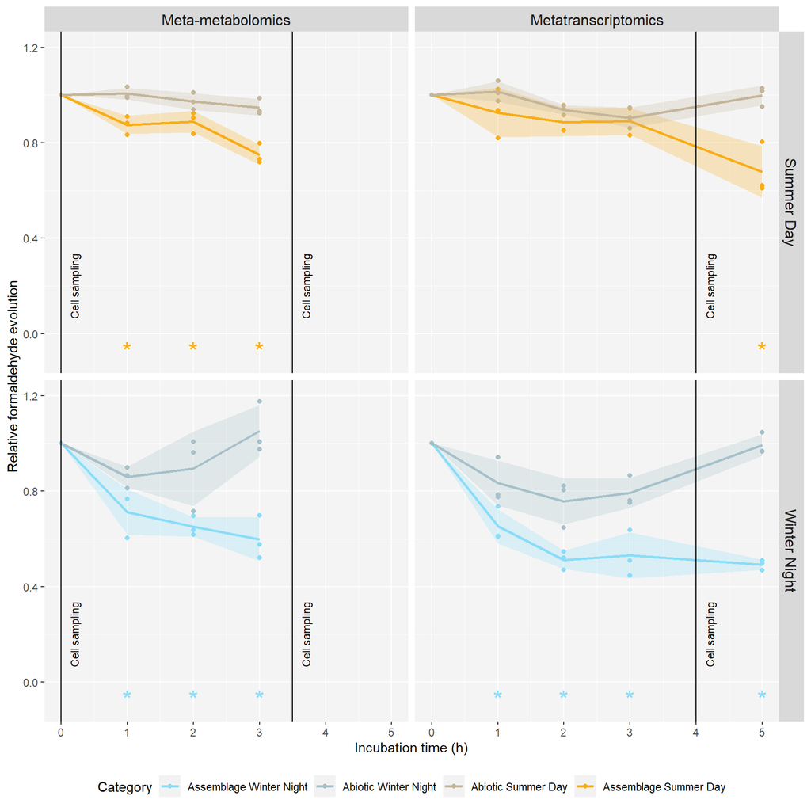

```r
  # plot significance stars
  geom_text(data=krusk[krusk$category == "community SD",],
            aes(x = time, y = height, label = pvalue, colour=color),
            size = 7, show.legend = FALSE, nudge_y = -0.07) +
  geom_text(data=krusk[krusk$category == "community WN",],
            aes(x = time, y = height, label = pvalue, colour=color),
            size = 7, show.legend = FALSE, nudge_y = -0.07) +
  geom_text(data=krusk[krusk$category == "abiotic SD",],
            aes(x = time, y = height, label = pvalue, colour=color),
            size = 7, show.legend = FALSE) +
  geom_text(data=krusk[krusk$category == "abiotic WN",],
            aes(x = time, y = height, label = pvalue, colour=color),
            size = 7, show.legend = FALSE) +

  geom_segment(data=segment_data, aes(x = x, xend = xend, y = y, yend = yend)) +
  geom_text(data=segment_data, aes(x = x + 0.2, y = 0.20, label = "Cell sampling"), angle=90, size=3) -> plot_formaldehyde

print(plot_formaldehyde)
```

```r
# ggsave(plot = plot_formaldehyde, filename = "../figures/formaldehyde_evolution.tiff", dpi = 300, width = 10, height = 6, bg="white")
```

### H2O2 evolution

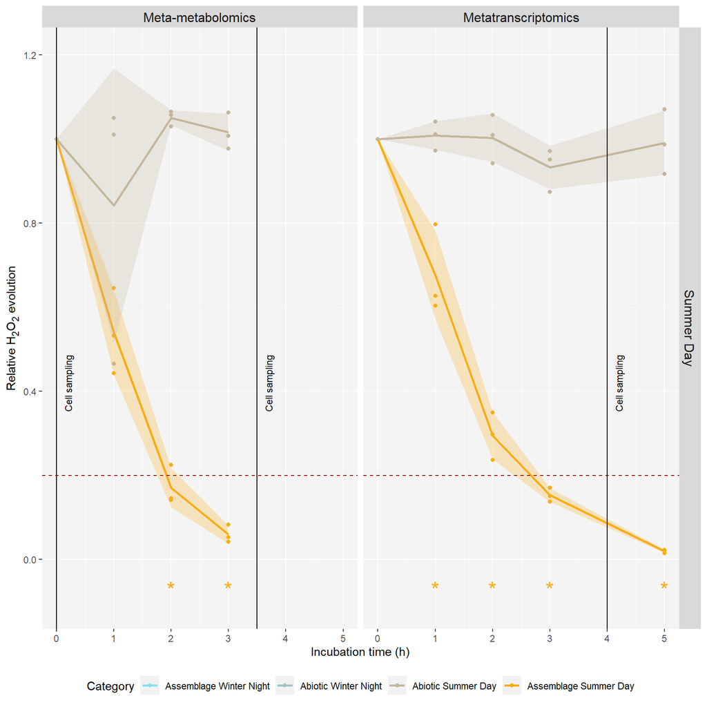

```r
chem_data_metaT$experiment <- "metaT"
chem_data_metaB$experiment <- "metaB"

chem_data <- rbind(chem_data_metaT, chem_data_metaB)



## Metatranscriptomics data

chem_data[chem_data$color == "#F8AD18" & chem_data$experiment == "metaT",] -> tmp2
group_by(tmp2, sampling_time) %>% summarise(H2O2_mean=mean(H2O2_ratio_to_initial),
                                            H2O2_sd=sd(H2O2_ratio_to_initial)) -> tmp2
tmp2$color <- "#F8AD18"
tmp2$condition <- "SD"
tmp2$category <- "biotic_SD"
tmp2$experiment <- "metaT"


chem_data[chem_data$color == "#C4B69B" & chem_data$experiment == "metaT",] -> tmp4
group_by(tmp4, sampling_time) %>% summarise(H2O2_mean=mean(H2O2_ratio_to_initial),
                                            H2O2_sd=sd(H2O2_ratio_to_initial)) -> tmp4
tmp4$color <- "#C4B69B"
tmp4$condition <- "SD"
tmp4$category <- "abiotic_SD"
tmp4$experiment <- "metaT"


## Metabolomics data

chem_data[chem_data$color == "#F8AD18" & chem_data$experiment == "metaB",] -> tmp6
group_by(tmp6, sampling_time) %>% summarise(H2O2_mean=mean(H2O2_ratio_to_initial),
                                            H2O2_sd=sd(H2O2_ratio_to_initial)) -> tmp6
tmp6$color <- "#F8AD18"
tmp6$condition <- "SD"
tmp6$category <- "biotic_SD"
tmp6$experiment <- "metaB"


chem_data[chem_data$color == "#C4B69B" & chem_data$experiment == "metaB",] -> tmp8
group_by(tmp8, sampling_time) %>% summarise(H2O2_mean=mean(H2O2_ratio_to_initial),
                                            H2O2_sd=sd(H2O2_ratio_to_initial)) -> tmp8
tmp8$color <- "#C4B69B"
tmp8$condition <- "SD"
tmp8$category <- "abiotic_SD"
tmp8$experiment <- "metaB"

chem_data$color <- as.factor(chem_data$color)
## Merge data

line_data <- rbind(tmp2, tmp4, tmp6, tmp8)
rm(tmp2, tmp4, tmp6, tmp8)

## Test difference between time 0 an the other time points

kruskal_h2o2 <-  c("",
                          try(if(kruskal.test(x = c(chem_data_metaB[(chem_data_metaB$sampling_time == 1 &
                                                                     chem_data_metaB$color == "#F8AD18"),
                                                                    "H2O2_ratio_to_initial"],
                                                    chem_data_metaB[(chem_data_metaB$sampling_time == 1 &
                                                                     chem_data_metaB$color == "#C4B69B"),
                                                                    "H2O2_ratio_to_initial"]),
                                              g = c(rep("biotic_SD", 3), rep("abiotic_SD", 3))
                          )[["p.value"]] < 0.05){"*"}else{""}, silent = TRUE) ,
                          try(if(kruskal.test(x = c(chem_data_metaB[(chem_data_metaB$sampling_time == 2 &
                                                                     chem_data_metaB$color == "#F8AD18"),
                                                                    "H2O2_ratio_to_initial"],
                                                    chem_data_metaB[(chem_data_metaB$sampling_time == 2 &
                                                                     chem_data_metaB$color == "#C4B69B"),
                                                                    "H2O2_ratio_to_initial"]),
                                              g = c(rep("biotic_SD", 3), rep("abiotic_SD", 3))
                          )[["p.value"]] < 0.05){"*"}else{""}, silent = TRUE),
                          try(if(kruskal.test(x = c(chem_data_metaB[(chem_data_metaB$sampling_time == 3 &
                                                                     chem_data_metaB$color == "#F8AD18"),
                                                                    "H2O2_ratio_to_initial"],
                                                    chem_data_metaB[(chem_data_metaB$sampling_time == 3 &
                                                                     chem_data_metaB$color == "#C4B69B"),
                                                                    "H2O2_ratio_to_initial"]),
                                              g = c(rep("biotic_SD", 3), rep("abiotic_SD", 3))
                          )[["p.value"]] < 0.05){"*"}else{""}, silent = TRUE),
                          "",
                          try(if(kruskal.test(x = c(chem_data_metaT[(chem_data_metaT$sampling_time == 1 &
                                                                     chem_data_metaT$color == "#F8AD18"),
                                                                    "H2O2_ratio_to_initial"],
                                                    chem_data_metaT[(chem_data_metaT$sampling_time == 1 &
                                                                     chem_data_metaT$color == "#C4B69B"),
                                                                    "H2O2_ratio_to_initial"]),
                                              g = c(rep("biotic_SD", 3), rep("abiotic_SD", 3))
                          )[["p.value"]] < 0.05){"*"}else{""}, silent = TRUE) ,
                          try(if(kruskal.test(x = c(chem_data_metaT[(chem_data_metaT$sampling_time == 2 &
                                                                     chem_data_metaT$color == "#F8AD18"),
                                                                    "H2O2_ratio_to_initial"],
                                                    chem_data_metaT[(chem_data_metaT$sampling_time == 2 &
                                                                     chem_data_metaT$color == "#C4B69B"),
                                                                    "H2O2_ratio_to_initial"]),
                                              g = c(rep("biotic_SD", 3), rep("abiotic_SD", 3))
                          )[["p.value"]] < 0.05){"*"}else{""}, silent = TRUE),
                          try(if(kruskal.test(x = c(chem_data_metaT[(chem_data_metaT$sampling_time == 3 &
                                                                     chem_data_metaT$color == "#F8AD18"),
                                                                    "H2O2_ratio_to_initial"],
                                                    chem_data_metaT[(chem_data_metaT$sampling_time == 3 &
                                                                     chem_data_metaT$color == "#C4B69B"),
                                                                    "H2O2_ratio_to_initial"]),
                                              g = c(rep("biotic_SD", 3), rep("abiotic_SD", 3))
                          )[["p.value"]] < 0.05){"*"}else{""}, silent = TRUE),
                          try(if(kruskal.test(x = c(chem_data_metaT[(chem_data_metaT$sampling_time == 5 &
                                                                     chem_data_metaT$color == "#F8AD18"),
                                                                    "H2O2_ratio_to_initial"],
                                                    chem_data_metaT[(chem_data_metaT$sampling_time == 5 &
                                                                     chem_data_metaT$color == "#C4B69B"),
                                                                    "H2O2_ratio_to_initial"]),
                                              g = c(rep("biotic_SD", 3), rep("abiotic_SD", 3))
                          )[["p.value"]] < 0.05){"*"}else{""}, silent = TRUE)
                     )

kruskal_df <- data.frame(time = c(0, 1, 2, 3, 0, 1, 2, 3, 5),
                         height = rep(0, 9),
                         experiment = c(rep("metaB", 4), rep("metaT", 5)),
                         condition = rep("SD", 9),
                         category = rep("community SD", 9),
                         color = rep("#F8AD18", 9),
                         pvalue = kruskal_h2o2)


krusk <- kruskal_df


## Segment data for sampling time

segment_data <- data.frame(x = c(4, 0, 3.5), xend = c(4, 0, 3.5),
                           y = c(-Inf, -Inf, -Inf), yend = c(Inf, Inf, Inf),
                           experiment = c("metaT", "metaB", "metaB"))

chem_data[chem_data$condition == "SD",] %>% ggplot() +
  geom_point(aes(x=sampling_time, y=H2O2_ratio_to_initial, color=color)) +
  ylim(c(-0.1, 1.2)) +
  xlim(c(0, 5)) +
  scale_colour_identity("Category", labels = c("Assemblage Winter Night", "Abiotic Winter Night",
                                               "Abiotic Summer Day", "Assemblage Summer Day"),
                        guide="legend", drop = FALSE) +
  scale_fill_identity() +

  ylab("Relative H<sub>2</sub>O<sub>2</sub> evolution") +
  xlab(label = "Incubation time (h)") +

  facet_grid(rows = vars(condition), cols = vars(experiment),
             labeller = as_labeller(c("metaT" = "Metatranscriptomics",
                                      "metaB" = "Meta-metabolomics",
                                      "SD" = "Summer Day",
                                      "WN" = "Winter Night"))) +
  theme(legend.position = "bottom",
        panel.background = element_rect(fill="#f4f4f4"),
        axis.title.y = element_markdown(),
        strip.text = element_text(size=12)) +


  geom_path(data = line_data[line_data$category == "biotic_SD",],
            aes(x = sampling_time, y = H2O2_mean, color = color),
            linewidth = 1) +
  geom_ribbon(data = line_data[line_data$category == "biotic_SD",],
              aes(x = sampling_time,
                  ymin = H2O2_mean - H2O2_sd,
                  ymax = H2O2_mean + H2O2_sd,
                  fill = color), alpha=0.25, linewidth=0.05) +

  geom_path(data = line_data[line_data$category == "abiotic_SD",],
            aes(x = sampling_time,y =H2O2_mean, color = color),
            linewidth = 1) +
  geom_ribbon(data = line_data[line_data$category == "abiotic_SD",],
              aes(x = sampling_time,
                  ymin = H2O2_mean - H2O2_sd,
                  ymax = H2O2_mean + H2O2_sd,
                  fill = color), alpha=0.25, linewidth=0.05) +

  # plot significance stars
  geom_text(data=krusk[krusk$category == "community SD",],
            aes(x = time, y = height, label = pvalue, colour=color),
            size = 7, show.legend = FALSE, nudge_y = -0.07) +
  geom_text(data=krusk[krusk$category == "abiotic SD",],
            aes(x = time, y = height, label = pvalue, colour=color),
            size = 7, show.legend = FALSE) +


  # geom_segment(aes(x=4, xend=4, y=-Inf, yend=Inf)) +
  geom_segment(data=segment_data, aes(x = x, xend = xend, y = y, yend = yend)) +
  geom_segment(aes(x = -Inf, xend = Inf, y = 0.2, yend = 0.2), colour = "darkred", linetype = 2) +
  geom_text(data=segment_data, aes(x = x + 0.2, y = 0.42, label = "Cell sampling"), angle=90, size=3) -> plot_h2o2

print(plot_h2o2)
```

```r
# ggsave(plot = plot_h2o2, filename = "../figures/H2O2_evolution.tiff", dpi = 300, width = 10, height = 3.6, bg="white")
```

```r
plot_chemical <- ggarrange(plot_h2o2, plot_formaldehyde,
                      labels = c("A", "B"),
                      common.legend=TRUE,
                      legend="bottom",
                      nrow=2,
                      heights = c(1.1, 1.9))


ggsave(plot = plot_chemical, filename = "../figures/Figure_S1.tiff", dpi = 300, width = 10, height = 10, bg="white")

# print(plot_chemical)
```

## Descriptive statistics on complete assemblage metatranscriptomics and metabolomics data

### Metatranscriptomics

#### Sample-wise statistics (raw metatranscriptomics counts)

```r
message("Computing sample-wise statistics on raw counts")
sample_stat_prenorm <- data.frame(
  mean = apply(counts_table, 2, mean, na.rm = TRUE),
  sd = apply(counts_table, 2, sd, na.rm = TRUE),
  iqr = apply(counts_table, 2, IQR, na.rm = TRUE),
  Q1 = apply(counts_table, 2, quantile, p = 0.25, na.rm = TRUE),
  median = apply(counts_table, 2, median, na.rm = TRUE),
  Q3 = apply(counts_table, 2, quantile, p = 0.75, na.rm = TRUE),
  max = apply(counts_table, 2, max, na.rm = TRUE),
  null = apply(counts_table == 0, 2, sum, na.rm = TRUE)
)
```

#### Gene-wise statistics (raw metatranscriptomics counts)

```r
message("Computing gene-wise statistics on raw counts")
gene_stat_prenorm <- data.frame(
  mean = apply(counts_table, 1, mean, na.rm = TRUE),
  sd = apply(counts_table, 1, sd, na.rm = TRUE),
  iqr = apply(counts_table, 1, IQR, na.rm = TRUE),
  Q1 = apply(counts_table, 1, quantile, p = 0.25, na.rm = TRUE),
  median = apply(counts_table, 1, median, na.rm = TRUE),
  Q3 = apply(counts_table, 1, quantile, p = 0.75, na.rm = TRUE),
  max = apply(counts_table, 1, max, na.rm = TRUE),
  null = apply(counts_table == 0, 1, sum, na.rm = TRUE)
)
```

#### Zeroes filtering and smoothing inspired by MTXmodel article [(Zhang et al. 2021)](https://doi.org/10.1093/bioinformatics/btab327)

```r
species <- unlist(unique(annotation_table[,"Organism"]))
samples <- row.names(metadata_table)
```

Gene with 0 counts in more than 70% of samples are deemed unexpressed and are removed from the dataset.

```r
message("Filtering undetected genes")
undetected_genes <- gene_stat_prenorm$null >= ncol(counts_table) * 0.70
print(paste0("Undetected genes (null in >= 70% samples): ", sum(undetected_genes)))
```

[1] “Undetected genes (null in >= 70% samples): 19262”

```r
kept_genes <- !undetected_genes
print(paste0("Kept genes: ", sum(kept_genes)))
```

[1] “Kept genes: 7191”

```r
## Genes after filtering
counts_filtered <- counts_table[kept_genes, ]
annotation_table <- annotation_all[rownames(counts_filtered),] #row.names()

## Species abundance (sum of all counts)
totals_df <- data.frame()
for (spe in species) {
  spe_geneid <- annotation_table$Organism == spe
  for (samp in samples) {
    totals_df[spe, samp] <- sum(counts_filtered[spe_geneid, samp], na.rm=TRUE)
  }
}
```

```r
# no standardisation was used afterall
counts_standard <- counts_filtered
table_gene_expr <- counts_table
table_gene_expr$detected <- "No"
table_gene_expr[kept_genes, "detected"] <- "yes"
table_gene_expr <- rownames_to_column(table_gene_expr)
table_gene_expr <- left_join(table_gene_expr, rownames_to_column(annotation_table_long)[,c("rowname", "locus_tag", "transcriptId")])
```

```r
## remaining zeroes smoothing (as in Zhang et al. 2021)

min_val <- apply(counts_standard, 1, function(x) (min(x[x>0])/2))


for (gene in row.names(counts_standard)) {
  counts_standard[gene,][counts_standard[gene,] == 0] <- min_val[gene]
}
```

```r
message("Computing sample-wise statistics on filtered counts")
sample_stat_filt <- data.frame(
  mean = apply(counts_standard, 2, mean, na.rm = TRUE),
  sd = apply(counts_standard, 2, sd, na.rm = TRUE),
  iqr = apply(counts_standard, 2, IQR, na.rm = TRUE),
  Q1 = apply(counts_standard, 2, quantile, p = 0.25, na.rm = TRUE),
  median = apply(counts_standard, 2, median, na.rm = TRUE),
  Q3 = apply(counts_standard, 2, quantile, p = 0.75, na.rm = TRUE),
  max = apply(counts_standard, 2, max, na.rm = TRUE),
  null = apply(counts_standard == 0, 2, sum, na.rm = TRUE)
)

kable(sample_stat_filt[0:6, ], caption = "Sample-wise statistics after filtering")
```

Sample-wise statistics after filtering

|  | mean | sd | iqr | Q1 | median | Q3 | max | null |
| --- | --- | --- | --- | --- | --- | --- | --- | --- |
| WN_TF_1 | 7.274402 | 153.42034 | 1.745 | 0.250 | 0.750 | 1.995 | 8701.91 | 0 |
| WN_TF_2 | 5.798768 | 141.55673 | 0.835 | 0.165 | 0.330 | 1.000 | 6777.67 | 0 |
| WN_TF_3 | 7.436439 | 154.65538 | 1.670 | 0.330 | 0.830 | 2.000 | 8361.50 | 0 |
| SD_TF_1 | 7.435202 | 192.23869 | 0.830 | 0.170 | 0.375 | 1.000 | 10856.58 | 0 |
| SD_TF_2 | 3.346716 | 85.01516 | 0.375 | 0.125 | 0.250 | 0.500 | 4582.83 | 0 |
| SD_TF_3 | 10.483380 | 285.44101 | 0.700 | 0.170 | 0.330 | 0.870 | 14318.75 | 0 |

#### CLR (Centered Log ratio) transformation of whole assemblage metatranscriptomics counts

```r
counts_clr <- counts_standard

for (samp in samples) {
  counts_clr[,samp] <- clr(counts_standard[,samp])
}
```

```r
message("Computing sample-wise statistics on filtered counts")
sample_stat_clr <- data.frame(
  mean = apply(counts_clr, 2, mean, na.rm = TRUE),
  sd = apply(counts_clr, 2, sd, na.rm = TRUE),
  iqr = apply(counts_clr, 2, IQR, na.rm = TRUE),
  Q1 = apply(counts_clr, 2, quantile, p = 0.25, na.rm = TRUE),
  median = apply(counts_clr, 2, median, na.rm = TRUE),
  Q3 = apply(counts_clr, 2, quantile, p = 0.75, na.rm = TRUE),
  max = apply(counts_clr, 2, max, na.rm = TRUE),
  null = apply(counts_clr == 0, 2, sum, na.rm = TRUE)
)

kable(sample_stat_clr[0:6, ], caption = "Sample-wise statistics after CLR transformation")
```

Sample-wise statistics after CLR transformation

|  | mean | sd | iqr | Q1 | median | Q3 | max | null |
| --- | --- | --- | --- | --- | --- | --- | --- | --- |
| WN_TF_1 | 0 | 1.366662 | 2.076935 | -1.1413059 | -0.0426936 | 0.9356294 | 9.316286 | 0 |
| WN_TF_2 | 0 | 1.246467 | 1.801810 | -0.9619634 | -0.2688162 | 0.8398464 | 9.661235 | 0 |
| WN_TF_3 | 0 | 1.357223 | 1.801810 | -0.9519112 | -0.0295782 | 0.8498986 | 9.188144 | 0 |
| SD_TF_1 | 0 | 1.220095 | 1.771957 | -0.9654242 | -0.1742966 | 0.8065326 | 10.099059 | 0 |
| SD_TF_2 | 0 | 1.061585 | 1.386294 | -0.8828711 | -0.1897239 | 0.5034233 | 9.626643 | 0 |
| SD_TF_3 | 0 | 1.204212 | 1.632695 | -0.9117566 | -0.2484624 | 0.7209382 | 10.429525 | 0 |

```r
## Gene-wise statistics after normalisation
message("Computing gene-wise statistics on log-transformed and normalised counts")
gene_stat_norm <- data.frame(mean = apply(counts_clr, 1, mean, na.rm=TRUE),
                             var = apply(counts_clr, 1, var, na.rm=TRUE),
                             sd = apply(counts_clr, 1, sd, na.rm=TRUE),
                             iqr = apply(counts_clr, 1, IQR, na.rm=TRUE),
                             min = apply(counts_clr, 1, min, na.rm=TRUE),
                             med = apply(counts_clr, 1, median, na.rm=TRUE),
                             max = apply(counts_clr, 1, max, na.rm=TRUE))

# Ajout du coefficient de variation
gene_stat_norm$coef_var <- (gene_stat_norm$sd / gene_stat_norm$mean)
```

#### Metatranscriptomics counts distribution

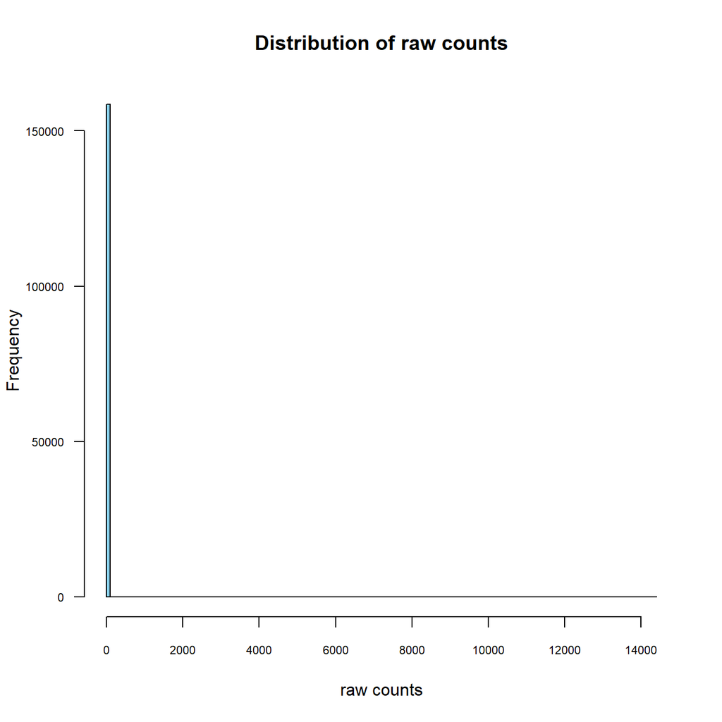

```r
par(mfrow=c(1,1))
hist(unlist(counts_table),
     breaks = 200,
     cex.axis = 0.7,
     las = 1,
     col = "skyblue",
     xlab = "raw counts",
     main = "Distribution of raw counts")
```

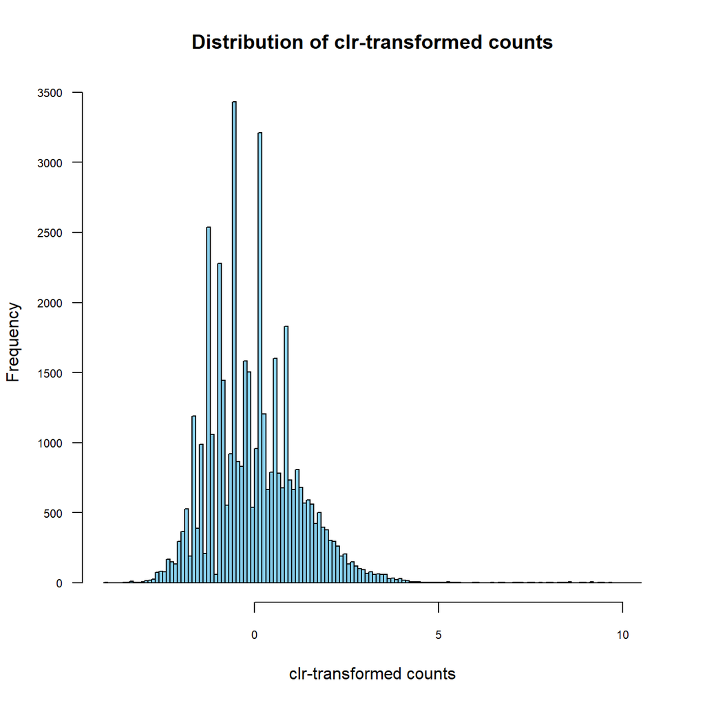

```r
par(mfrow=c(1,1))
hist(unlist(counts_clr),
     breaks = 200,
     cex.axis = 0.7,
     las = 1,
     col = "skyblue",
     xlab = "clr-transformed counts",
     main = "Distribution of clr-transformed counts")
```

The distribution of the whole assemblage metatranscriptomics counts seems close to normal.

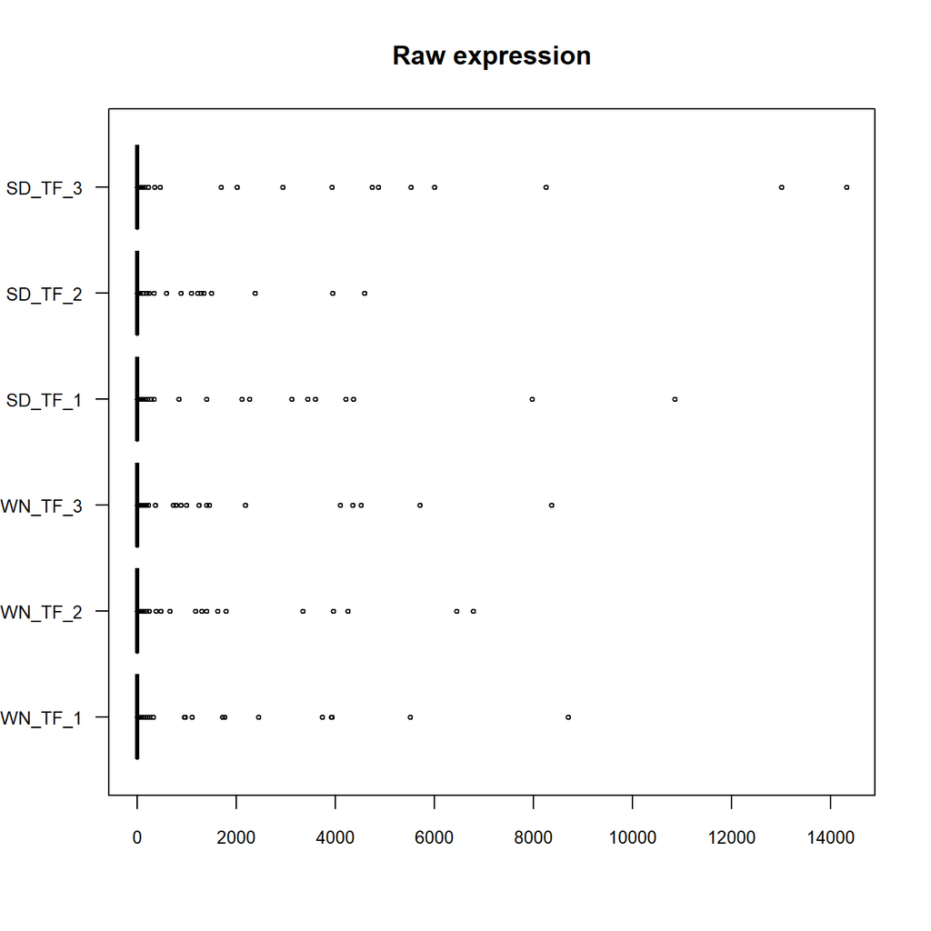

```r
# Raw data
boxplot(counts_table,
        main = "Raw expression",
        horizontal = TRUE,
        col = metadata_table$color,
        cex = 0.5,
        cex.axis = 0.8,
        las = 1)
```

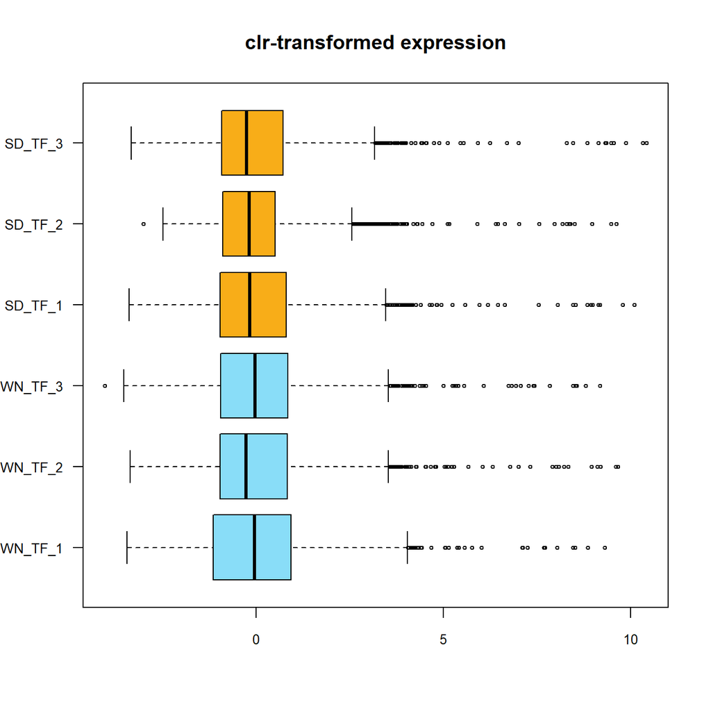

```r
boxplot(counts_clr,
        main = "clr-transformed expression",
        horizontal = TRUE,
        col = metadata_table$color,
        cex = 0.5,
        cex.axis = 0.8,
        las = 1)
```

The CLR transformation centred our data.

#### Assemblage metatranscriptomics counts repartition by species

```r
totals_df$species <- row.names((totals_df))
totals_df %>%
    pivot_longer(!species,
                names_to=c("sample"),
                values_to="total_counts") %>%
  mutate(sample = case_when(sample == "SD_TF_1" ~ "SD_TF_1",
                            sample == "SD_TF_2" ~ "SD_TF_2",
                            sample == "SD_TF_3" ~ "SD_TF_3",
                            sample == "WN_TF_1" ~ "WN_TF_1",
                            sample == "WN_TF_2" ~ "WN_TF_2",
                            sample == "WN_TF_3" ~ "WN_TF_3")) -> totals_df
```

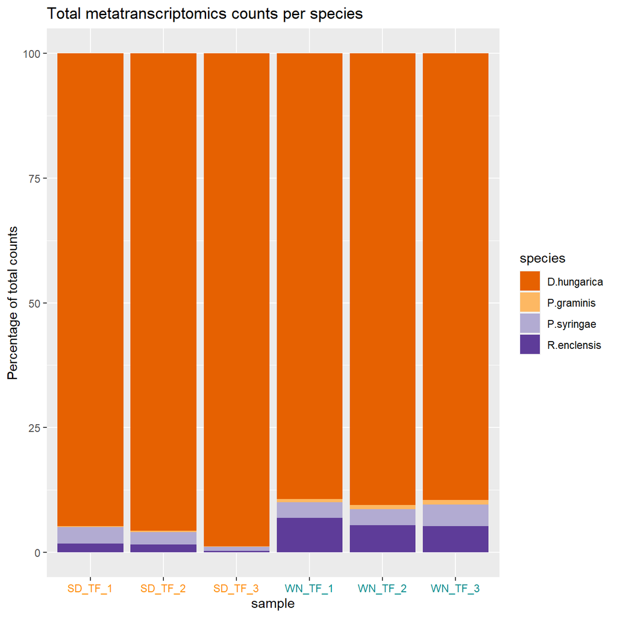

```r
ggplot(data=totals_df, mapping=aes(x=sample, y=total_counts, fill=species)) +
  geom_bar(position="fill", stat="identity") +
  scale_fill_brewer(palette = "PuOr") +
  labs(y = "Percentage of total counts") +
  scale_y_continuous(labels = as_function(~ 100 * .)) +
  theme(axis.text.x = element_text(colour = c("SD_TF_1" = "darkorange",
                                              "SD_TF_2" = "darkorange",
                                              "SD_TF_3" = "darkorange",
                                              "WN_TF_1" = "darkcyan",
                                              "WN_TF_2" = "darkcyan",
                                              "WN_TF_3" = "darkcyan"))) +
  ggtitle("Total metatranscriptomics counts per species") -> p

print(p)
```

```r
ggsave("../figures/Figure_S3_counts_repartition.png", p, dpi = 300)
ggsave("../figures/Figure_S3_counts_repartition.tiff", p, height = 7, width = 7, dpi = 300)
```

As previously noted, *Dioszegia hungarica* counts are largely dominant in our data. *Pseudomonas graminis* associated counts are very rare.

##### *D. hungarica* filtered counts repartition by nucleus or mitochondrial origin

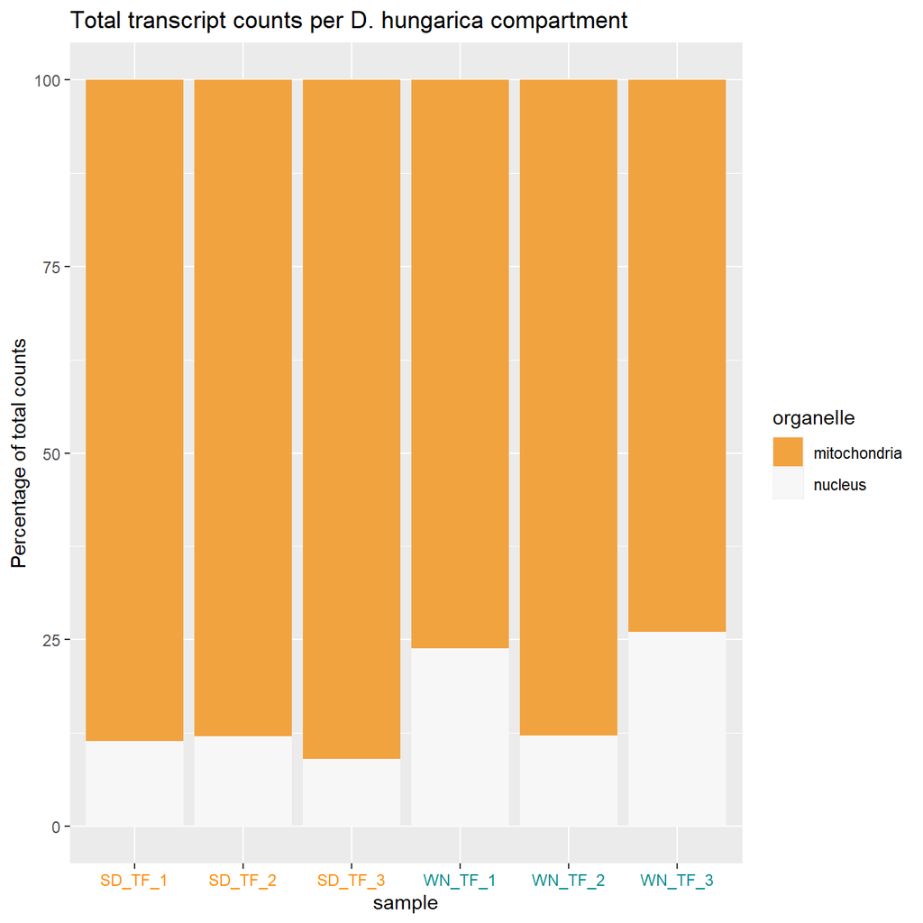

```r
organelle_df <- data.frame()

mito_geneid <- annotation_table$Chr == "Dioszegia_hungarica_PDD-24b-2_contig_35"
nucl_geneid <- (annotation_table$Organism == "D.hungarica" & annotation_table$Chr != "Dioszegia_hungarica_PDD-24b-2_contig_35")

for (samp in samples) {
    organelle_df["mitochondria", samp] <- sum(counts_filtered[mito_geneid, samp], na.rm=TRUE)
    organelle_df["nucleus", samp] <- sum(counts_filtered[nucl_geneid, samp], na.rm=TRUE)
}

organelle_df$organelle <- row.names((organelle_df))
organelle_df %>%
    pivot_longer(!organelle,
                names_to=c("sample"),
                values_to="total_counts") %>%
  mutate(sample = case_when(sample == "SD_TF_1" ~ "SD_TF_1",
                            sample == "SD_TF_2" ~ "SD_TF_2",
                            sample == "SD_TF_3" ~ "SD_TF_3",
                            sample == "WN_TF_1" ~ "WN_TF_1",
                            sample == "WN_TF_2" ~ "WN_TF_2",
                            sample == "WN_TF_3" ~ "WN_TF_3")) -> organelle_df

ggplot(data=organelle_df, mapping=aes(x=sample, y=total_counts, fill=organelle)) +
  geom_bar(position="fill", stat="identity") +
  scale_fill_brewer(palette = "PuOr") +
  labs(y = "Percentage of total counts") +
  scale_y_continuous(labels = as_function(~ 100 * .)) +
  theme(axis.text.x = element_text(colour = c("SD_TF_1" = "darkorange",
                                              "SD_TF_2" = "darkorange",
                                              "SD_TF_3" = "darkorange",
                                              "WN_TF_1" = "darkcyan",
                                              "WN_TF_2" = "darkcyan",
                                              "WN_TF_3" = "darkcyan"))) +
  ggtitle("Total transcript counts per D. hungarica compartment") -> p

print(p)
```

```r
ggsave("../figures/Diohu_counts_repartition.png", p, dpi = 300)
ggsave("../figures/Diohu_counts_repartition.tiff", p, height = 7, width = 7, dpi = 300)
```

**Among *Dioszegia hungarica* counts, a large portion come from transcripts produced in the mitochondria, especially in SD conditions.**

### Metabolomics

#### Metabolite-wise statistics (raw data)

```r
# message("Computing metabolite-wise statistics on raw counts")

metabolite_stat_prenorm <- data.frame(
  mean = apply(metabolomics_all_times_df, 1, mean, na.rm = TRUE),
  sd = apply(metabolomics_all_times_df, 1, sd, na.rm = TRUE),
  iqr = apply(metabolomics_all_times_df, 1, IQR, na.rm = TRUE),
  Q1 = apply(metabolomics_all_times_df, 1, quantile, p = 0.25, na.rm = TRUE),
  median = apply(metabolomics_all_times_df, 1, median, na.rm = TRUE),
  Q3 = apply(metabolomics_all_times_df, 1, quantile, p = 0.75, na.rm = TRUE),
  max = apply(metabolomics_all_times_df, 1, max, na.rm = TRUE),
  null = apply(metabolomics_all_times_df == 0, 1, sum, na.rm = TRUE)
)

kable(metabolite_stat_prenorm[100:109, ], caption = "Gene-wise statistics before normalisation")
```

Gene-wise statistics before normalisation

|  | mean | sd | iqr | Q1 | median | Q3 | max | null |
| --- | --- | --- | --- | --- | --- | --- | --- | --- |
| M227.1754T7.46 | 0.0297637 | 0.0125831 | 0.0153123 | 0.0216464 | 0.0248620 | 0.0369588 | 0.0545123 | 0 |
| M227.1756T7.71 | 0.0009423 | 0.0005382 | 0.0005236 | 0.0006028 | 0.0008935 | 0.0011263 | 0.0023538 | 0 |
| M229.1547T7.3 | 0.0002872 | 0.0000654 | 0.0001292 | 0.0002224 | 0.0002810 | 0.0003516 | 0.0003785 | 0 |
| M229.1548T7.51 | 0.0002844 | 0.0000405 | 0.0000395 | 0.0002643 | 0.0002889 | 0.0003038 | 0.0003452 | 0 |
| M231.1704T7.41 | 0.0007549 | 0.0004071 | 0.0004789 | 0.0004242 | 0.0006295 | 0.0009030 | 0.0015536 | 0 |
| M231.1704T7.7 | 0.0007458 | 0.0003289 | 0.0004379 | 0.0004945 | 0.0007700 | 0.0009324 | 0.0013820 | 0 |
| M231.1705T8.71 | 0.0001531 | 0.0000906 | 0.0001410 | 0.0000854 | 0.0001604 | 0.0002264 | 0.0002715 | 0 |
| M232.1544T7.21 | 0.0019758 | 0.0016928 | 0.0009050 | 0.0010000 | 0.0011673 | 0.0019050 | 0.0056565 | 0 |
| M232.1544T7.07 | 0.0010623 | 0.0005972 | 0.0005553 | 0.0006736 | 0.0007847 | 0.0012289 | 0.0021863 | 0 |
| M233.0592T7.35 | 0.0000623 | 0.0000277 | 0.0000356 | 0.0000442 | 0.0000653 | 0.0000798 | 0.0001143 | 0 |

#### Zero filtering and smoothing metabolomics

Metabolites with 0 counts in more than 70% of samples are deemed unexpressed and are removed from the dataset.

```r
message("Filtering undetected metabolites")
undetected_metabolites <- metabolite_stat_prenorm$null >= ncol(metabolomics_all_times_df) * 0.70
print(paste0("undetected_metabolites (null in >= 70% samples): ", sum(undetected_metabolites)))
```

[1] “undetected_metabolites (null in >= 70% samples): 5”

```r
kept_metabolites <- !undetected_metabolites
print(paste0("Kept metabolites: ", sum(kept_metabolites)))
```

[1] “Kept metabolites: 465”

```r
## metabolites after filtering
metabolomics_all_times_filtered <- metabolomics_all_times_df[kept_metabolites, ]
```

```r
## remaining zeroes smoothing (as in Zhang et al. 2021)

min_val <- apply(metabolomics_all_times_filtered, 1, function(x) (min(x[x>0])/2))


for (metabolite in row.names(metabolomics_all_times_filtered)) {
  metabolomics_all_times_filtered[metabolite,][metabolomics_all_times_filtered[metabolite,] == 0] <- min_val[metabolite]
}
```

#### CLR transformation metabolomics

```r
metabolomics_all_times_clr <- metabolomics_all_times_filtered

for (samp in names(metabolomics_all_times_filtered )){
  metabolomics_all_times_clr[,samp] <- as.vector(clr(metabolomics_all_times_filtered[,samp]))
}
```

#### Metabolomics data repartition

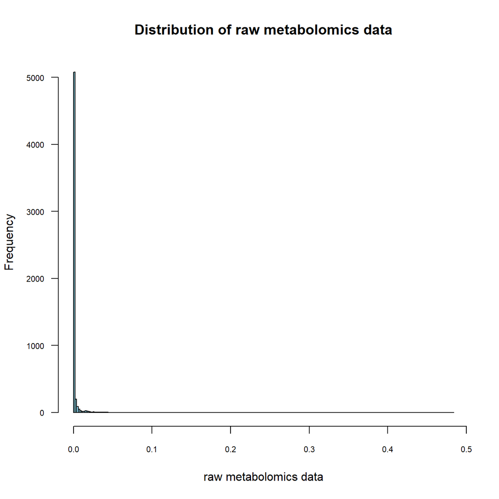

```r
par(mfrow=c(1,1))
hist(unlist(metabolomics_all_times_df),
     breaks = 200,
     cex.axis = 0.7,
     las = 1,
     col = "skyblue",
     xlab = "raw metabolomics data",
     main = "Distribution of raw metabolomics data")
```

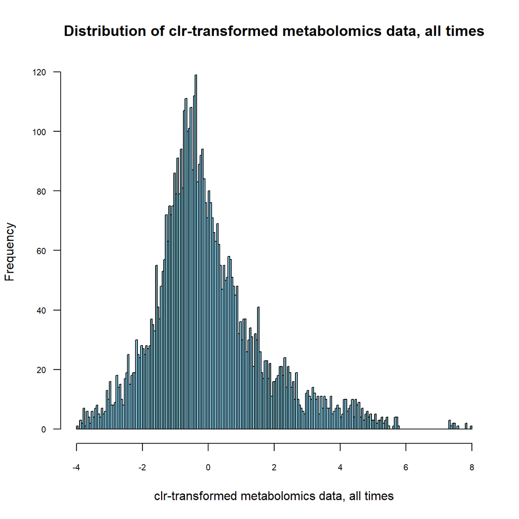

```r
par(mfrow=c(1,1))
hist(unlist(metabolomics_all_times_clr),
     breaks = 200,
     cex.axis = 0.7,
     las = 1,
     col = "skyblue",
     xlab = "clr-transformed metabolomics data, all times",
     main = "Distribution of clr-transformed metabolomics data, all times")
```

The distribution of metabolomics data is close to normal.

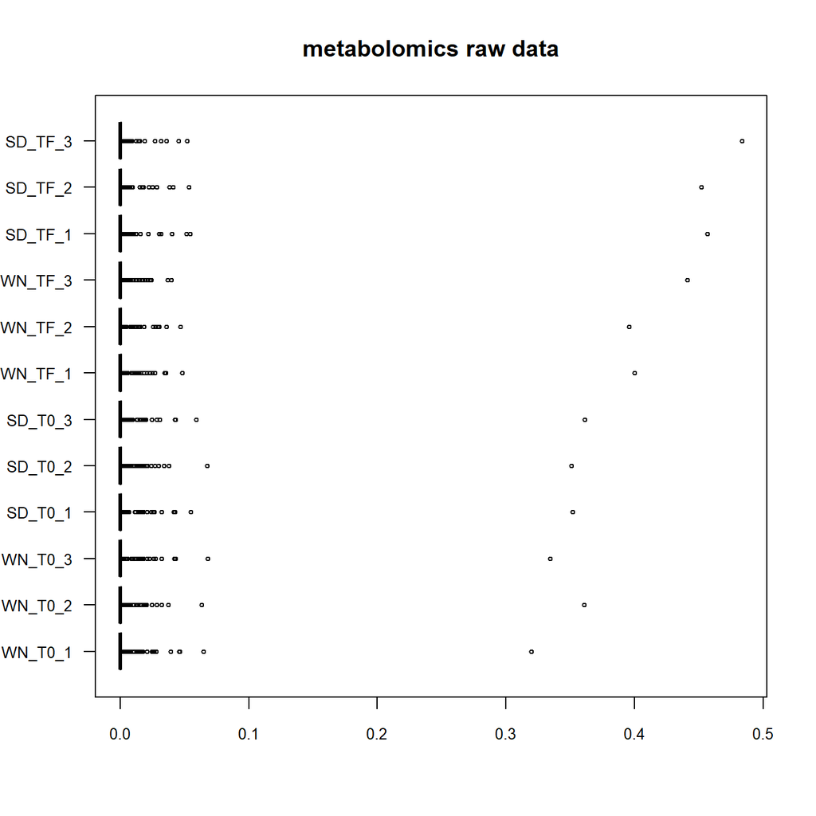

```r
boxplot(metabolomics_all_times_df,
        main = "metabolomics raw data",
        horizontal = TRUE,
        col = metadata_table_metaB_all_times$color,
        cex = 0.5,
        cex.axis = 0.8,
        las = 1)
```

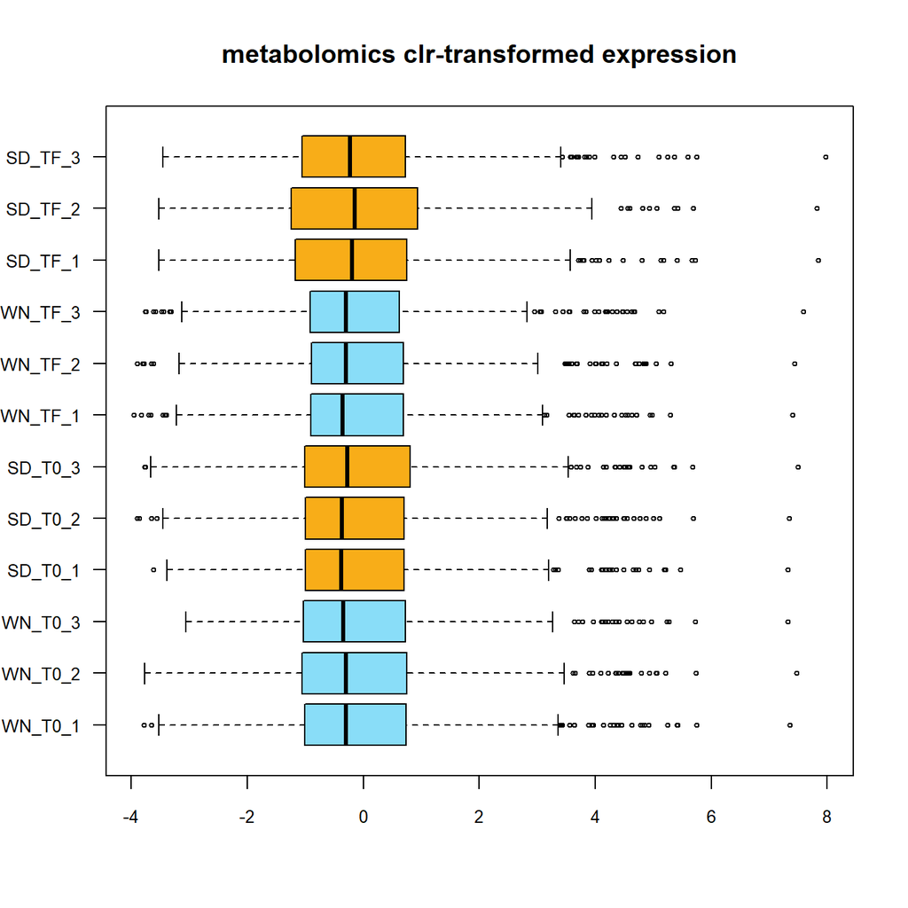

```r
boxplot(metabolomics_all_times_clr,
        main = "metabolomics clr-transformed expression",
        horizontal = TRUE,
        col = metadata_table_metaB_all_times$color,
        cex = 0.5,
        cex.axis = 0.8,
        las = 1)
```

The CLR transformation centred our data.

## Exploratory statistical analyses of the whole assemblage

### Principal Component Analyses (PCA) metatranscriptomic

```r
par(mfrow = c(2,2))
res_pca <- PCA(t(counts_clr), scale.unit = TRUE, graph = FALSE)
```

```r
counts_data <- t(counts_clr)
metadata_tmp <- data.frame(metadata_table, stringsAsFactors = TRUE)
permanova <- adonis2(formula = as.formula(paste0("counts_data~", "condition")),
                     data = metadata_tmp, method="euclidean", # method="bray", #otu_data~TIME
                     permutations = 999, sqrt.dist = FALSE, add = FALSE, by = "terms")
pv = permanova$`Pr(>F)`[1]
# print(pv)

rm(counts_data, metadata_tmp)
```

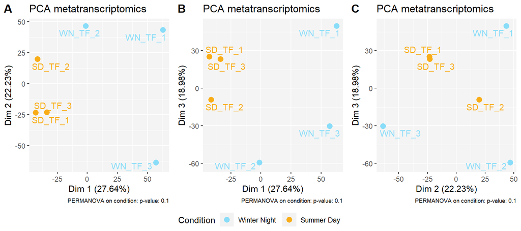

```r
pca_tmp <- rbind(res_pca$ind$coord,
                 res_pca$ind.sup$coord) %>% data.frame() %>%
  rownames_to_column("sample")


pca_data <- left_join(pca_tmp, rownames_to_column(metadata_table), by=join_by("sample" == "rowname"))
rm(pca_tmp)

D1_text = paste0("Dim 1 (",
                 round(data.frame(res_pca$eig)$percentage.of.variance[1], digits=2),
                 "%)")
D2_text = paste0("Dim 2 (",
                 round(data.frame(res_pca$eig)$percentage.of.variance[2], digits=2),
                 "%)")
D3_text = paste0("Dim 3 (",
                 round(data.frame(res_pca$eig)$percentage.of.variance[3], digits=2),
                 "%)")

ggplot(pca_data) +
  geom_point(aes(x=Dim.1, y=Dim.2, colour=color, ), size=3) +
  scale_colour_identity("Condition", labels=c("Winter Night", "Summer Day"), guide = "legend") +
  ggrepel::geom_text_repel(aes(x=Dim.1, y=Dim.2, colour=color, label=sample),
                           nudge_y = -2,  seed = 42, segment.size=0.1, show.legend = FALSE) +
  xlab(D1_text) +
  ylab(D2_text) +
  ggtitle("PCA metatranscriptomics") +
  labs(caption =  paste0("PERMANOVA on condition: p-value: ", pv)) +
  theme(panel.background= element_rect(fill="#f4f4f4"),
        plot.caption = element_text(size=7)) -> p1_metaT


ggplot(pca_data) +
  geom_point(aes(x=Dim.1, y=Dim.3, colour=color), size=3) +
  scale_colour_identity("Condition", labels=c("Winter Night", "Summer Day"), guide = "legend") +
  ggrepel::geom_text_repel(aes(x=Dim.1, y=Dim.3, colour=color, label=sample),
                           nudge_y = -2,  seed = 42, segment.size=0.1, show.legend = FALSE) +
  xlab(D1_text) +
  ylab(D3_text) +
  ggtitle("PCA metatranscriptomics") +
  labs(caption =  paste0("PERMANOVA on condition: p-value: ", pv)) +
  theme(panel.background= element_rect(fill="#f4f4f4"),
        plot.caption = element_text(size=7)) -> p2

ggplot(pca_data) +
  geom_point(aes(x=Dim.2, y=Dim.3, colour=color), size=3) +
  scale_colour_identity("Condition", labels=c("Winter Night", "Summer Day"), guide = "legend") +
  ggrepel::geom_text_repel(aes(x=Dim.2, y=Dim.3, colour=color, label=sample),
                           nudge_y = -2,  seed = 42, segment.size=0.1, show.legend = FALSE) +
  xlab(D2_text) +
  ylab(D3_text) +
  ggtitle("PCA metatranscriptomics") +
  labs(caption =  paste0("PERMANOVA on condition: p-value: ", pv)) +
  theme(panel.background= element_rect(fill="#f4f4f4"),
        plot.caption = element_text(size=7)) -> p3

plotgrid_PCA <- ggarrange(p1_metaT, p2, p3, labels = c("A", "B", "C"), common.legend=TRUE, legend="bottom", nrow=1)

print(plotgrid_PCA)
```

```r
ggsave(plot = plotgrid_PCA, filename = "../figures/PCA_metatranscriptomics_3_composantes.tiff", dpi = 300, width = 15, height = 5, bg="white")

ggsave(plot=p1_metaT, filename = "../figures/PCA_metatranscriptomics.tiff", dpi = 300, width = 6, height = 5, bg="white")
```

```r
row_coord <- res_pca$ind$coord

invisible(rgl::open3d())

#rgl::bg3d("lightgray")
rgl::plot3d(x=row_coord[c("WN_TF_1", "WN_TF_2", "WN_TF_3"), 1],
            y=row_coord[c("WN_TF_1", "WN_TF_2", "WN_TF_3"), 2],
            z=row_coord[c("WN_TF_1", "WN_TF_2", "WN_TF_3"), 3],
            xlab = paste0(colnames(row_coord)[1] , " (" , substr(as.character(res_pca$eig[,2][1]), 1, 5) , "%)"),
            ylab = paste0(colnames(row_coord)[2] , " (" , substr(as.character(res_pca$eig[,2][2]), 1, 5) , "%)"),
            zlab = paste0(colnames(row_coord)[3] , " (" , substr(as.character(res_pca$eig[,2][3]), 1, 5) , "%)"),
            xlim = c(min(row_coord[, 1]-10), max(row_coord[, 1])+10),
            ylim = c(min(row_coord[, 2]-10), max(row_coord[, 2])+10),
            zlim = c(min(row_coord[, 3]-10), max(row_coord[, 3])+10),
            col = "darkcyan",
            size=10,
            main = "PCA Assemblage")

rgl::text3d(x=row_coord[c("WN_TF_1", "WN_TF_2", "WN_TF_3"), 1]+5,
            y=row_coord[c("WN_TF_1", "WN_TF_2", "WN_TF_3"), 2]+5,
            z=row_coord[c("WN_TF_1", "WN_TF_2", "WN_TF_3"), 3]+5,
            text=c("WN_TF_1", "WN_TF_2", "WN_TF_3"),
            col = "darkcyan",
            size=10)


rgl::points3d(x=row_coord[c("SD_TF_1", "SD_TF_2", "SD_TF_3"), 1],
              y=row_coord[c("SD_TF_1", "SD_TF_2", "SD_TF_3"), 2],
              z=row_coord[c("SD_TF_1", "SD_TF_2", "SD_TF_3"), 3],
              col = "darkorange",
              size=10)

rgl::text3d(x=row_coord[c("SD_TF_1", "SD_TF_2", "SD_TF_3"), 1]+5,
            y=row_coord[c("SD_TF_1", "SD_TF_2", "SD_TF_3"), 2]+5,
            z=row_coord[c("SD_TF_1", "SD_TF_2", "SD_TF_3"), 3]+5,
            text=c("SD_TF_1", "SD_TF_2", "SD_TF_3"),
            col = "darkorange",
            size=10)

# Activate for or gif generation
par3d(windowRect = c(20, 30, 800, 800))

# rgl::movie3d(
#  movie="3dAnimated_PCA_metaT_assemblage",
#  spin3d( axis = c(0, 0, 1), rpm = 3),
#  duration = 20,
#  dir = "../figures",
#  type = "gif",
#  clean = TRUE, webshot=FALSE, fps=20)
```

[interactive chart not shown]

### PCA metabolomics

```r
par(mfrow = c(2,2))
res_pca_metaB_all_times <- PCA(t(metabolomics_all_times_clr), scale.unit = TRUE, graph = FALSE)
```

```r
metabolomics_data <- t(metabolomics_all_times_clr)
metabolomics_tmp <- data.frame(metadata_table_metaB_all_times, stringsAsFactors = TRUE)
permanova <- adonis2(formula = as.formula(paste0("metabolomics_data~", "condition")),
                     data = metabolomics_tmp, method="euclidean",
                     permutations = 999, sqrt.dist = FALSE, add = FALSE, by = "terms")
pv = permanova$`Pr(>F)`[1]

rm(metabolomics_data, metabolomics_tmp)
```

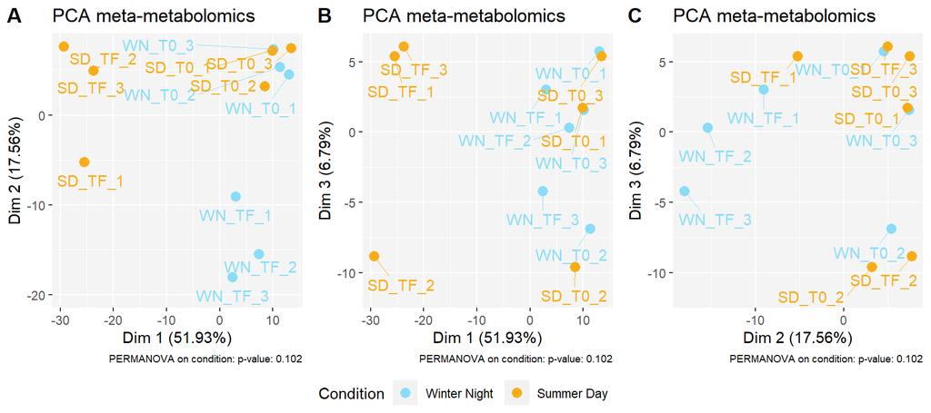

```r
pca_tmp_metaB <- rbind(res_pca_metaB_all_times$ind$coord,
                 res_pca_metaB_all_times$ind.sup$coord) %>% data.frame() %>%
  rownames_to_column("sample")


pca_data_metaB <- left_join(pca_tmp_metaB, rownames_to_column(metadata_table_metaB_all_times), by=join_by("sample" == "rowname"))
rm(pca_tmp_metaB)

D1_text = paste0("Dim 1 (",
                 round(data.frame(res_pca_metaB_all_times$eig)$percentage.of.variance[1], digits=2),
                 "%)")
D2_text = paste0("Dim 2 (",
                 round(data.frame(res_pca_metaB_all_times$eig)$percentage.of.variance[2], digits=2),
                 "%)")
D3_text = paste0("Dim 3 (",
                 round(data.frame(res_pca_metaB_all_times$eig)$percentage.of.variance[3], digits=2),
                 "%)")

ggplot(pca_data_metaB) +
  geom_point(aes(x=Dim.1, y=Dim.2, colour=color, ), size=3) +
  scale_colour_identity("Condition", labels=c("Winter Night", "Summer Day"), guide = "legend") +
  ggrepel::geom_text_repel(aes(x=Dim.1, y=Dim.2, colour=color, label=sample),
                           nudge_y = -2,  seed = 42, segment.size=0.1, show.legend = FALSE) +
  xlab(D1_text) +
  ylab(D2_text) +
  ggtitle("PCA meta-metabolomics") +
  labs(caption =  paste0("PERMANOVA on condition: p-value: ", pv)) +
  theme(panel.background= element_rect(fill="#f4f4f4"),
        plot.caption = element_text(size=7)) -> p1_metaB


ggplot(pca_data_metaB) +
  geom_point(aes(x=Dim.1, y=Dim.3, colour=color), size=3) +
  scale_colour_identity("Condition", labels=c("Winter Night", "Summer Day"), guide = "legend") +
  ggrepel::geom_text_repel(aes(x=Dim.1, y=Dim.3, colour=color, label=sample),
                           nudge_y = -2,  seed = 42, segment.size=0.1, show.legend = FALSE) +
  xlab(D1_text) +
  ylab(D3_text) +
  ggtitle("PCA meta-metabolomics") +
  labs(caption =  paste0("PERMANOVA on condition: p-value: ", pv)) +
  theme(panel.background= element_rect(fill="#f4f4f4"),
        plot.caption = element_text(size=7)) -> p2_metaB

ggplot(pca_data_metaB) +
  geom_point(aes(x=Dim.2, y=Dim.3, colour=color), size=3) +
  scale_colour_identity("Condition", labels=c("Winter Night", "Summer Day"), guide = "legend") +
  ggrepel::geom_text_repel(aes(x=Dim.2, y=Dim.3, colour=color, label=sample),
                           nudge_y = -2,  seed = 42, segment.size=0.1, show.legend = FALSE) +
  xlab(D2_text) +
  ylab(D3_text) +
  ggtitle("PCA meta-metabolomics") +
  labs(caption =  paste0("PERMANOVA on condition: p-value: ", pv)) +
  theme(panel.background= element_rect(fill="#f4f4f4"),
        plot.caption = element_text(size=7)) -> p3_metaB

plotgrid_PCA_metaB <- ggarrange(p1_metaB, p2_metaB, p3_metaB, labels = c("A", "B", "C"), common.legend=TRUE, legend="bottom", nrow=1)

print(plotgrid_PCA_metaB)
```

```r
ggsave(plot = p1_metaB, filename = "../figures/PCA_metabolomics_all_times.tiff", dpi = 300, width = 5, height = 5, bg="white")

ggsave(plot = plotgrid_PCA_metaB, filename = "../figures/PCA_metabolomics_3_composantes_all_times.tiff", dpi = 300, width = 15, height = 5, bg="white")

ggsave(plot=p1_metaB, filename = "../figures/PCA_metabolomics_all_times.tiff", dpi = 300, width = 6, height = 5, bg="white")
```

```r
row_coord <- res_pca_metaB_all_times$ind$coord

invisible(rgl::open3d())

#rgl::bg3d("lightgray")
rgl::plot3d(x=row_coord[c("WN_TF_1", "WN_TF_2", "WN_TF_3"), 1],
            y=row_coord[c("WN_TF_1", "WN_TF_2", "WN_TF_3"), 2],
            z=row_coord[c("WN_TF_1", "WN_TF_2", "WN_TF_3"), 3],
            xlab = paste0(colnames(row_coord)[1] , " (" , substr(as.character(res_pca$eig[,2][1]), 1, 5) , "%)"),
            ylab = paste0(colnames(row_coord)[2] , " (" , substr(as.character(res_pca$eig[,2][2]), 1, 5) , "%)"),
            zlab = paste0(colnames(row_coord)[3] , " (" , substr(as.character(res_pca$eig[,2][3]), 1, 5) , "%)"),
            xlim = c(min(row_coord[, 1]-10), max(row_coord[, 1])+10),
            ylim = c(min(row_coord[, 2]-10), max(row_coord[, 2])+10),
            zlim = c(min(row_coord[, 3]-10), max(row_coord[, 3])+10),
            col = "darkcyan",
            size=10,
            main = "PCA meta-metabolomics assemblage")

rgl::text3d(x=row_coord[c("WN_TF_1", "WN_TF_2", "WN_TF_3"), 1]+5,
            y=row_coord[c("WN_TF_1", "WN_TF_2", "WN_TF_3"), 2]+5,
            z=row_coord[c("WN_TF_1", "WN_TF_2", "WN_TF_3"), 3]+5,
            text=c("WN_TF_1", "WN_TF_2", "WN_TF_3"),
            col = "darkcyan",
            size=10)


rgl::points3d(x=row_coord[c("SD_TF_1", "SD_TF_2", "SD_TF_3"), 1],
              y=row_coord[c("SD_TF_1", "SD_TF_2", "SD_TF_3"), 2],
              z=row_coord[c("SD_TF_1", "SD_TF_2", "SD_TF_3"), 3],
              col = "darkorange",
              size=10)

rgl::text3d(x=row_coord[c("SD_TF_1", "SD_TF_2", "SD_TF_3"), 1]+5,
            y=row_coord[c("SD_TF_1", "SD_TF_2", "SD_TF_3"), 2]+5,
            z=row_coord[c("SD_TF_1", "SD_TF_2", "SD_TF_3"), 3]+5,
            text=c("SD_TF_1", "SD_TF_2", "SD_TF_3"),
            col = "darkorange",
            size=10)


rgl::points3d(x=row_coord[c("WN_T0_1", "WN_T0_2", "WN_T0_3"), 1],
              y=row_coord[c("WN_T0_1", "WN_T0_2", "WN_T0_3"), 2],
              z=row_coord[c("WN_T0_1", "WN_T0_2", "WN_T0_3"), 3],
              col = "darkcyan",
              size=10)

rgl::text3d(x=row_coord[c("WN_T0_1", "WN_T0_2", "WN_T0_3"), 1]+5,
            y=row_coord[c("WN_T0_1", "WN_T0_2", "WN_T0_3"), 2]+5,
            z=row_coord[c("WN_T0_1", "WN_T0_2", "WN_T0_3"), 3]+5,
            text=c("WN_T0_1", "WN_T0_2", "WN_T0_3"),
            col = "darkcyan",
            size=10)


rgl::points3d(x=row_coord[c("SD_T0_1", "SD_T0_2", "SD_T0_3"), 1],
              y=row_coord[c("SD_T0_1", "SD_T0_2", "SD_T0_3"), 2],
              z=row_coord[c("SD_T0_1", "SD_T0_2", "SD_T0_3"), 3],
              col = "darkorange",
              size=10)

rgl::text3d(x=row_coord[c("SD_T0_1", "SD_T0_2", "SD_T0_3"), 1]+5,
            y=row_coord[c("SD_T0_1", "SD_T0_2", "SD_T0_3"), 2]+5,
            z=row_coord[c("SD_T0_1", "SD_T0_2", "SD_T0_3"), 3]+5,
            text=c("SD_T0_1", "SD_T0_2", "SD_T0_3"),
            col = "darkorange",
            size=10)



# Activate for or gif generation
# par3d(windowRect = c(20, 30, 800, 800))
#
# rgl::movie3d(
#  movie="3dAnimated_PCA_metaB_assemblage",
#  spin3d( axis = c(0, 0, 1), rpm = 3),
#  duration = 20,
#  dir = "../figures",
#  type = "gif",
#  clean = TRUE, webshot=FALSE, fps=20)
```

[interactive chart not shown]

```r
plot_all <- ggarrange(p1_metaB, p1_metaT,
                      labels = c("A", "B"),
                      common.legend=TRUE,
                      legend="bottom",
                      nrow=1,
                      widths = c(1, 1))

ggsave(plot = plot_all, filename = "../figures/Figure_2.tiff", dpi = 300, width = 11, height = 6, bg="white")
```

## Individual exploratory analysis of metatranscriptomics data by species

#### Load data by species

```r
diohu_geneid <- annotation_table$Organism == "D.hungarica"
diohu_df <- counts_standard[startsWith(rownames_to_column(counts_standard)$rowname, "D.hungarica"),]

psesy_geneid <- annotation_table$Organism == "P.syringae"
psesy_df <- counts_standard[startsWith(rownames_to_column(counts_standard)$rowname, "P.syringae"),]

psegr_geneid <- annotation_table$Organism == "P.graminis"
psegr_df <- counts_standard[startsWith(rownames_to_column(counts_standard)$rowname, "P.graminis"),]

rhoen_geneid <- annotation_table$Organism == "R.enclensis"
rhoen_df <- counts_standard[startsWith(rownames_to_column(counts_standard)$rowname, "R.enclensis"),]
```

#### Zeroes smoothing by species

```r
## remaining zeroes smoothing (as in Zhang et al. 2021)
min_val <- apply(diohu_df, 1, function(x) (min(x[x>0])/2))
for (gene in row.names(diohu_df)) {
  diohu_df[gene,][diohu_df[gene,] == 0] <- min_val[gene]
}

min_val <- apply(psesy_df, 1, function(x) (min(x[x>0])/2))
for (gene in row.names(psesy_df)) {
  psesy_df[gene,][psesy_df[gene,] == 0] <- min_val[gene]
}

min_val <- apply(psegr_df, 1, function(x) (min(x[x>0])/2))
for (gene in row.names(psegr_df)) {
  psegr_df[gene,][psegr_df[gene,] == 0] <- min_val[gene]
}

min_val <- apply(rhoen_df, 1, function(x) (min(x[x>0])/2))
for (gene in row.names(rhoen_df)) {
  rhoen_df[gene,][rhoen_df[gene,] == 0] <- min_val[gene]
}
```

#### CLR Transformation of counts by species

```r
diohu_clr <- diohu_df
psesy_clr <- psesy_df
psegr_clr <- psegr_df
rhoen_clr <- rhoen_df

for (samp in samples) {
    diohu_clr[,samp] <- as.vector(clr(diohu_df[,samp]))
    psesy_clr[,samp] <- as.vector(clr(psesy_df[,samp]))
    psegr_clr[,samp] <- as.vector(clr(psegr_df[,samp]))
    rhoen_clr[,samp] <- as.vector(clr(rhoen_df[,samp]))
}
```

### Transcriptomics counts histograms by species

#### *Dioszegia hungarica*

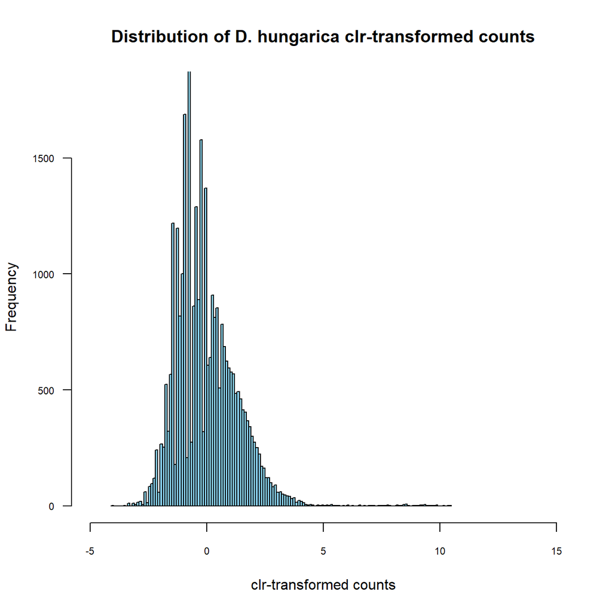

```r
par(mfrow=c(1,1))
hist(unlist(diohu_clr),
     breaks = 200,
     cex.axis = 0.7,
     las = 1,
     col = "skyblue",
     ylim = c(0,1800),
     xlim = c(-5,15),
     xlab = "clr-transformed counts",
     main = "Distribution of D. hungarica clr-transformed counts")
```

#### *Pseudomonas graminis*

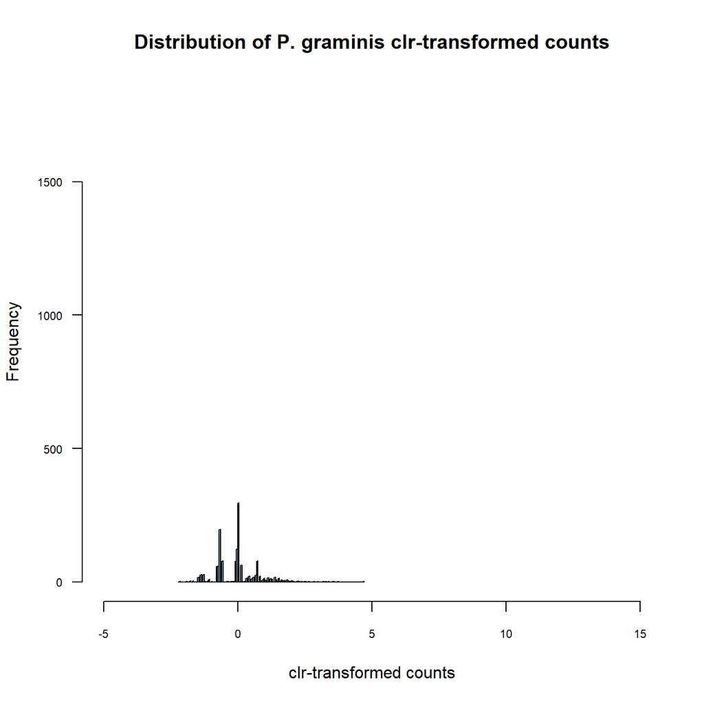

```r
par(mfrow=c(1,1))
hist(unlist(psegr_clr),
     breaks = 200,
     cex.axis = 0.7,
     las = 1,
     col = "skyblue",
     ylim = c(0,1800),
     xlim = c(-5,15),
     xlab = "clr-transformed counts",
     main = "Distribution of P. graminis clr-transformed counts")
```

Very few *P. graminis* counts, probably not exploitable.

#### *Pseudomonas syringae*

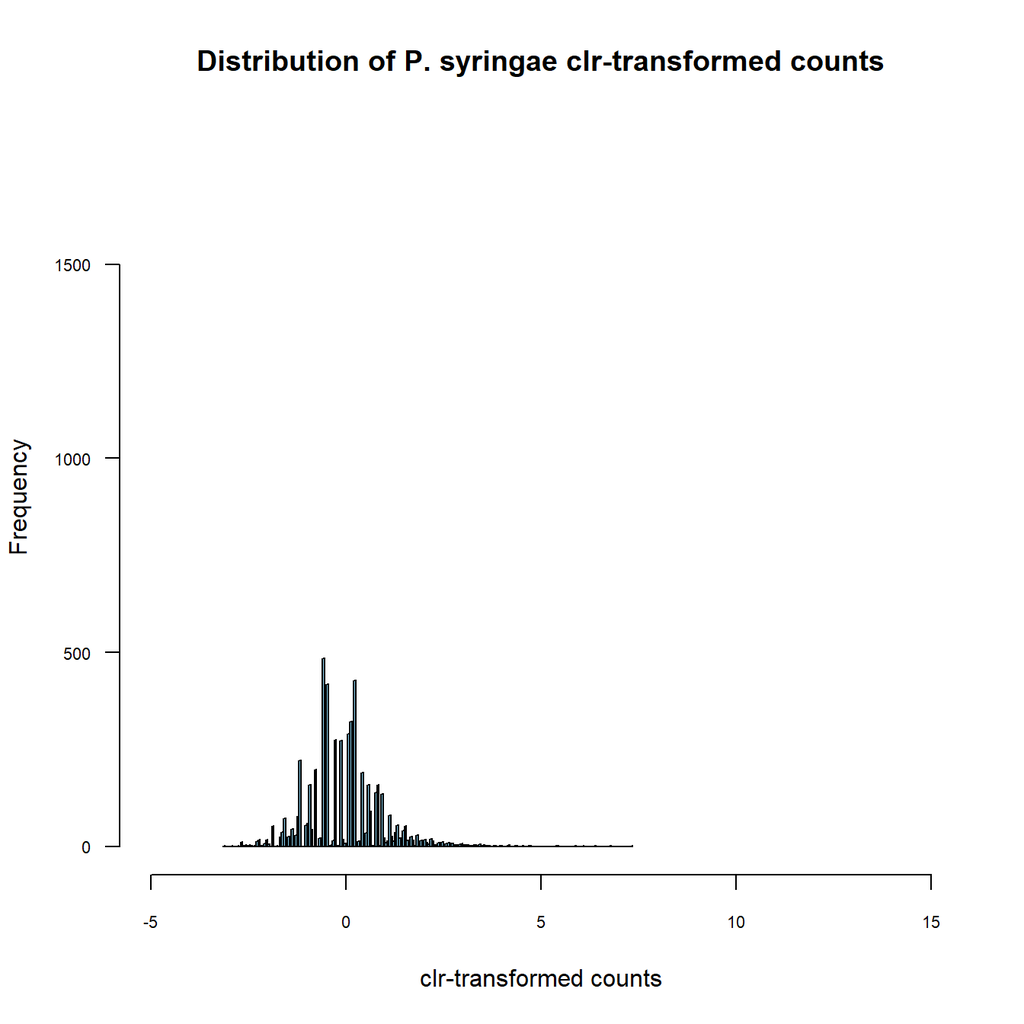

```r
par(mfrow=c(1,1))
hist(unlist(psesy_clr),
     breaks = 200,
     cex.axis = 0.7,
     las = 1,
     col = "skyblue",
     ylim = c(0,1800),
     xlim = c(-5,15),
     xlab = "clr-transformed counts",
     main = "Distribution of P. syringae clr-transformed counts")
```

#### *Rhodococcus enclensis*

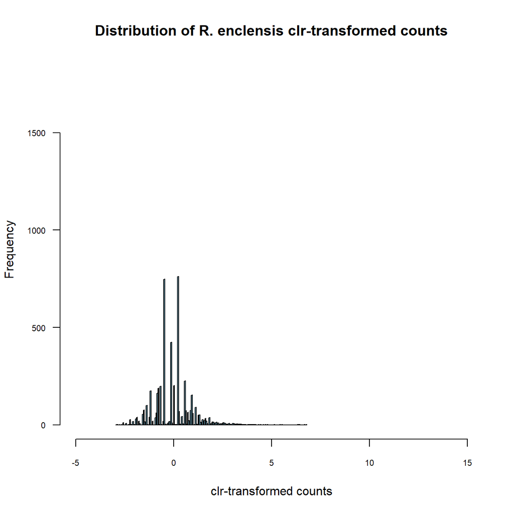

```r
par(mfrow=c(1,1))
hist(unlist(rhoen_clr),
     breaks = 200,
     cex.axis = 0.7,
     las = 1,
     col = "skyblue",
     ylim = c(0,1800),
     xlim = c(-5,15),
     xlab = "clr-transformed counts",
     main = "Distribution of R. enclensis clr-transformed counts")
```

### Transcriptomics counts box-plots by species

#### *Dioszegia hungarica*

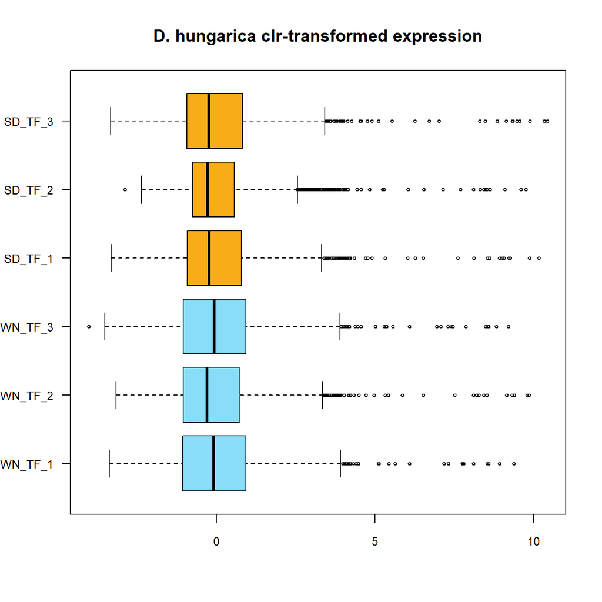

```r
boxplot(diohu_clr,
        main = "D. hungarica clr-transformed expression",
        horizontal = TRUE,
        col = metadata_table$color,
        cex = 0.5,
        cex.axis = 0.8,
        las = 1)
```

#### *Pseudomonas graminis*

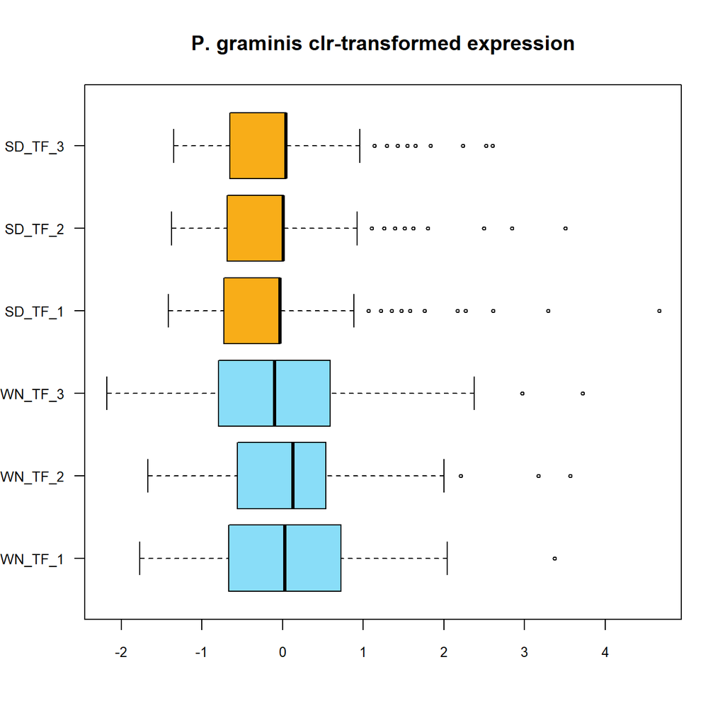

```r
boxplot(psegr_clr,
        main = "P. graminis clr-transformed expression",
        horizontal = TRUE,
        col = metadata_table$color,
        cex = 0.5,
        cex.axis = 0.8,
        las = 1)
```

#### *Pseudomonas syringae*

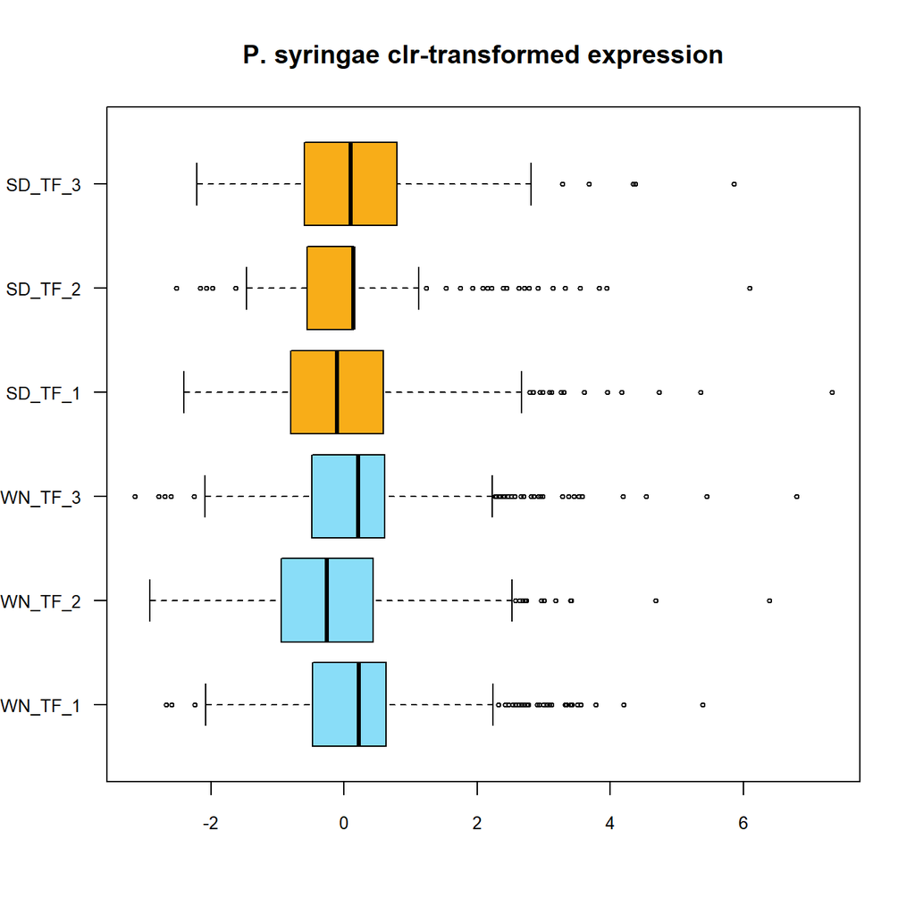

```r
boxplot(psesy_clr,
        main = "P. syringae clr-transformed expression",
        horizontal = TRUE,
        col = metadata_table$color,
        cex = 0.5,
        cex.axis = 0.8,
        las = 1)
```

#### *Rhodococcus enclensis*

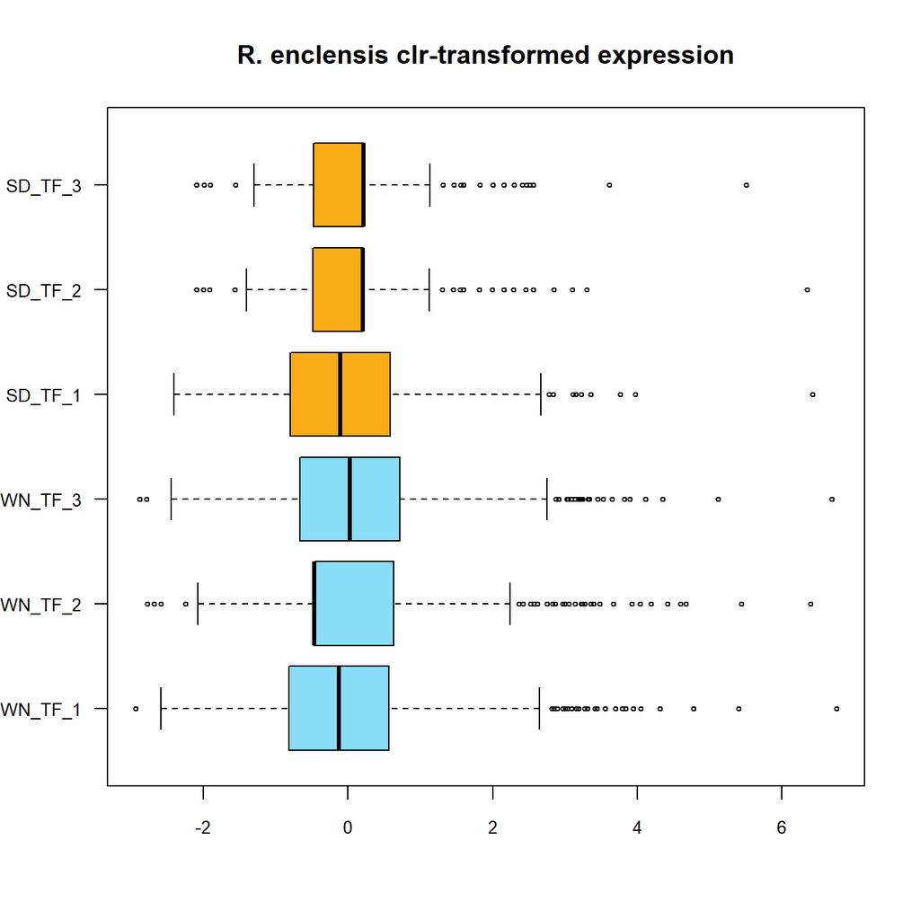

```r
boxplot(rhoen_clr,
        main = "R. enclensis clr-transformed expression",
        horizontal = TRUE,
        col = metadata_table$color,
        cex = 0.5,
        cex.axis = 0.8,
        las = 1)
```

### Transcriptomics counts PCA by species

#### *Dioszegia hungarica*

```r
res_pca <- PCA(t(diohu_clr), scale.unit = TRUE, graph = FALSE)
```

```r
counts_data <- t(diohu_clr)
metadata_tmp <- data.frame(metadata_table, stringsAsFactors = TRUE)
permanova <- adonis2(formula = as.formula(paste0("counts_data~", "condition")),
                     data = metadata_tmp, method="euclidean", # method="bray", #otu_data~TIME
                     permutations = 999, sqrt.dist = FALSE, add = FALSE, by = "terms")
pv = permanova$`Pr(>F)`[1]

rm(counts_data, metadata_tmp)
```

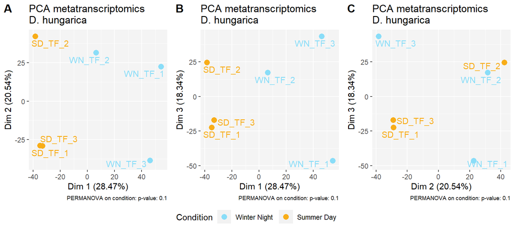

```r
pca_tmp <- rbind(res_pca$ind$coord,
                 res_pca$ind.sup$coord) %>% data.frame() %>%
  rownames_to_column("sample")


pca_data <- left_join(pca_tmp, rownames_to_column(metadata_table), by=join_by("sample" == "rowname"))
rm(pca_tmp)

D1_text = paste0("Dim 1 (",
                 round(data.frame(res_pca$eig)$percentage.of.variance[1], digits=2),
                 "%)")
D2_text = paste0("Dim 2 (",
                 round(data.frame(res_pca$eig)$percentage.of.variance[2], digits=2),
                 "%)")
D3_text = paste0("Dim 3 (",
                 round(data.frame(res_pca$eig)$percentage.of.variance[3], digits=2),
                 "%)")

ggplot(pca_data) +
  geom_point(aes(x=Dim.1, y=Dim.2, colour=color, ), size=3) +
  scale_colour_identity("Condition", labels=c("Winter Night", "Summer Day"), guide = "legend") +
  ggrepel::geom_text_repel(aes(x=Dim.1, y=Dim.2, colour=color, label=sample),
                           nudge_y = -2,  seed = 42, segment.size=0.1, show.legend = FALSE) +
  xlab(D1_text) +
  ylab(D2_text) +
  ggtitle("PCA metatranscriptomics  \nD. hungarica") +
  labs(caption =  paste0("PERMANOVA on condition: p-value: ", pv)) +
  theme(panel.background= element_rect(fill="#f4f4f4"),
        plot.caption = element_text(size=7)) -> p1


ggplot(pca_data) +
  geom_point(aes(x=Dim.1, y=Dim.3, colour=color), size=3) +
  scale_colour_identity("Condition", labels=c("Winter Night", "Summer Day"), guide = "legend") +
  ggrepel::geom_text_repel(aes(x=Dim.1, y=Dim.3, colour=color, label=sample),
                           nudge_y = -2,  seed = 42, segment.size=0.1, show.legend = FALSE) +
  xlab(D1_text) +
  ylab(D3_text) +
  ggtitle("PCA metatranscriptomics  \nD. hungarica") +
  labs(caption =  paste0("PERMANOVA on condition: p-value: ", pv)) +
  theme(panel.background= element_rect(fill="#f4f4f4"),
        plot.caption = element_text(size=7)) -> p2

ggplot(pca_data) +
  geom_point(aes(x=Dim.2, y=Dim.3, colour=color), size=3) +
  scale_colour_identity("Condition", labels=c("Winter Night", "Summer Day"), guide = "legend") +
  ggrepel::geom_text_repel(aes(x=Dim.2, y=Dim.3, colour=color, label=sample),
                           nudge_y = -2,  seed = 42, segment.size=0.1, show.legend = FALSE) +
  xlab(D2_text) +
  ylab(D3_text) +
  ggtitle("PCA metatranscriptomics  \nD. hungarica") +
  labs(caption =  paste0("PERMANOVA on condition: p-value: ", pv)) +
  theme(panel.background= element_rect(fill="#f4f4f4"),
        plot.caption = element_text(size=7)) -> p3

plotgrid_PCA <- ggarrange(p1, p2, p3, labels = c("A", "B", "C"), common.legend=TRUE, legend="bottom", nrow=1)

print(plotgrid_PCA)
```

```r
ggsave(plot = plotgrid_PCA, filename = "../figures/PCA_metatranscriptomics_3_composantes_diohu.tiff", dpi = 300, width = 15, height = 5, bg="white")

ggsave(plot=p1, filename = "../figures/PCA_metatranscriptomics_diohu.tiff", dpi = 300, width = 6, height = 5, bg="white")
```

```r
row_coord <- res_pca$ind$coord


invisible(rgl::open3d())

#rgl::bg3d("lightgray")
rgl::plot3d(x=row_coord[c("WN_TF_1", "WN_TF_2", "WN_TF_3"), 1],
            y=row_coord[c("WN_TF_1", "WN_TF_2", "WN_TF_3"), 2],
            z=row_coord[c("WN_TF_1", "WN_TF_2", "WN_TF_3"), 3],
            xlab = paste0(colnames(row_coord)[1] , " (" , substr(as.character(res_pca$eig[,2][1]), 1, 5) , "%)"),
            ylab = paste0(colnames(row_coord)[2] , " (" , substr(as.character(res_pca$eig[,2][2]), 1, 5) , "%)"),
            zlab = paste0(colnames(row_coord)[3] , " (" , substr(as.character(res_pca$eig[,2][3]), 1, 5) , "%)"),
            xlim = c(min(row_coord[, 1]), max(row_coord[, 1])+10),
            ylim = c(min(row_coord[, 2]), max(row_coord[, 2])+10),
            zlim = c(min(row_coord[, 3]), max(row_coord[, 3])+10),
            col = "darkcyan",
            size=10,
            main = "PCA D. hungarica")

rgl::text3d(x=row_coord[c("WN_TF_1", "WN_TF_2", "WN_TF_3"), 1]+5,
            y=row_coord[c("WN_TF_1", "WN_TF_2", "WN_TF_3"), 2]+5,
            z=row_coord[c("WN_TF_1", "WN_TF_2", "WN_TF_3"), 3]+5,
            text=c("WN_TF_1", "WN_TF_2", "WN_TF_3"),
            col = "darkcyan",
            size=10)


rgl::points3d(x=row_coord[c("SD_TF_1", "SD_TF_2", "SD_TF_3"), 1],
              y=row_coord[c("SD_TF_1", "SD_TF_2", "SD_TF_3"), 2],
              z=row_coord[c("SD_TF_1", "SD_TF_2", "SD_TF_3"), 3],
              col = "darkorange",
              size=10)

rgl::text3d(x=row_coord[c("SD_TF_1", "SD_TF_2", "SD_TF_3"), 1]+5,
            y=row_coord[c("SD_TF_1", "SD_TF_2", "SD_TF_3"), 2]+5,
            z=row_coord[c("SD_TF_1", "SD_TF_2", "SD_TF_3"), 3]+5,
            text=c("SD_TF_1", "SD_TF_2", "SD_TF_3"),
            col = "darkorange",
            size=10)

## Activate for or gif generation
#par3d(windowRect = c(20, 30, 800, 800))

#rgl::movie3d(
#  movie="3DAnimated_PCA_diohu",
#  spin3d( axis = c(0, 0, 1), rpm = 3),
#  duration = 20,
#  dir = "../figures",
#  type = "gif",
#  clean = TRUE, webshot=FALSE, fps=10)
```

[interactive chart not shown]

#### *Pseudomonas graminis*

```r
res_pca <- PCA(t(psegr_clr), scale.unit = TRUE, graph = FALSE)
```

```r
counts_data <- t(psegr_clr)
metadata_tmp <- data.frame(metadata_table, stringsAsFactors = TRUE)
permanova <- adonis2(formula = as.formula(paste0("counts_data~", "condition")),
                     data = metadata_tmp, method="euclidean", # method="bray", #otu_data~TIME
                     permutations = 999, sqrt.dist = FALSE, add = FALSE, by = "terms")
pv = permanova$`Pr(>F)`[1]
# print(pv)

rm(counts_data, metadata_tmp)
```

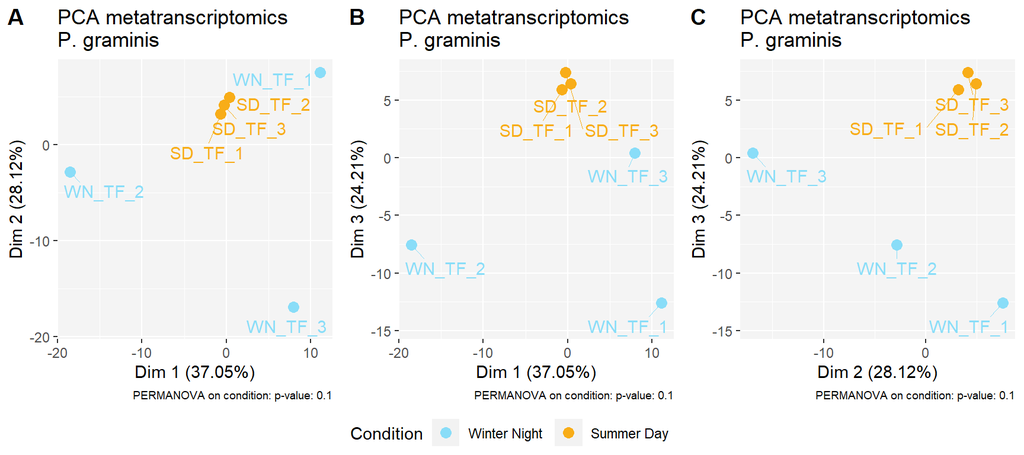

```r
pca_tmp <- rbind(res_pca$ind$coord,
                 res_pca$ind.sup$coord) %>% data.frame() %>%
  rownames_to_column("sample")


pca_data <- left_join(pca_tmp, rownames_to_column(metadata_table), by=join_by("sample" == "rowname"))
rm(pca_tmp)

D1_text = paste0("Dim 1 (",
                 round(data.frame(res_pca$eig)$percentage.of.variance[1], digits=2),
                 "%)")
D2_text = paste0("Dim 2 (",
                 round(data.frame(res_pca$eig)$percentage.of.variance[2], digits=2),
                 "%)")
D3_text = paste0("Dim 3 (",
                 round(data.frame(res_pca$eig)$percentage.of.variance[3], digits=2),
                 "%)")

ggplot(pca_data) +
  geom_point(aes(x=Dim.1, y=Dim.2, colour=color, ), size=3) +
  scale_colour_identity("Condition", labels=c("Winter Night", "Summer Day"), guide = "legend") +
  ggrepel::geom_text_repel(aes(x=Dim.1, y=Dim.2, colour=color, label=sample),
                           nudge_y = -2,  seed = 42, segment.size=0.1, show.legend = FALSE) +
  xlab(D1_text) +
  ylab(D2_text) +
  ggtitle("PCA metatranscriptomics  \nP. graminis") +
  labs(caption =  paste0("PERMANOVA on condition: p-value: ", pv)) +
  theme(panel.background= element_rect(fill="#f4f4f4"),
        plot.caption = element_text(size=7)) -> p1


ggplot(pca_data) +
  geom_point(aes(x=Dim.1, y=Dim.3, colour=color), size=3) +
  scale_colour_identity("Condition", labels=c("Winter Night", "Summer Day"), guide = "legend") +
  ggrepel::geom_text_repel(aes(x=Dim.1, y=Dim.3, colour=color, label=sample),
                           nudge_y = -2,  seed = 42, segment.size=0.1, show.legend = FALSE) +
  xlab(D1_text) +
  ylab(D3_text) +
  ggtitle("PCA metatranscriptomics  \nP. graminis") +
  labs(caption =  paste0("PERMANOVA on condition: p-value: ", pv)) +
  theme(panel.background= element_rect(fill="#f4f4f4"),
        plot.caption = element_text(size=7)) -> p2

ggplot(pca_data) +
  geom_point(aes(x=Dim.2, y=Dim.3, colour=color), size=3) +
  scale_colour_identity("Condition", labels=c("Winter Night", "Summer Day"), guide = "legend") +
  ggrepel::geom_text_repel(aes(x=Dim.2, y=Dim.3, colour=color, label=sample),
                           nudge_y = -2,  seed = 42, segment.size=0.1, show.legend = FALSE) +
  xlab(D2_text) +
  ylab(D3_text) +
  ggtitle("PCA metatranscriptomics  \nP. graminis") +
  labs(caption =  paste0("PERMANOVA on condition: p-value: ", pv)) +
  theme(panel.background= element_rect(fill="#f4f4f4"),
        plot.caption = element_text(size=7)) -> p3

plotgrid_PCA <- ggarrange(p1, p2, p3, labels = c("A", "B", "C"), common.legend=TRUE, legend="bottom", nrow=1)

print(plotgrid_PCA)
```

```r
ggsave(plot = plotgrid_PCA, filename = "../figures/PCA_metatranscriptomics_3_composantes_psegr.tiff", dpi = 300, width = 15, height = 5, bg="white")

ggsave(plot=p1, filename = "../figures/PCA_metatranscriptomics_psegr.tiff", dpi = 300, width = 6, height = 5, bg="white")
```

```r
row_coord <- res_pca$ind$coord

invisible(rgl::open3d())

#rgl::bg3d("lightgray")
rgl::plot3d(x=row_coord[c("WN_TF_1", "WN_TF_2", "WN_TF_3"), 1],
            y=row_coord[c("WN_TF_1", "WN_TF_2", "WN_TF_3"), 2],
            z=row_coord[c("WN_TF_1", "WN_TF_2", "WN_TF_3"), 3],
            xlab = paste0(colnames(row_coord)[1] , " (" , substr(as.character(res_pca$eig[,2][1]), 1, 5) , "%)"),
            ylab = paste0(colnames(row_coord)[2] , " (" , substr(as.character(res_pca$eig[,2][2]), 1, 5) , "%)"),
            zlab = paste0(colnames(row_coord)[3] , " (" , substr(as.character(res_pca$eig[,2][3]), 1, 5) , "%)"),
            xlim = c(min(row_coord[, 1]), max(row_coord[, 1])+10),
            ylim = c(min(row_coord[, 2]), max(row_coord[, 2])+10),
            zlim = c(min(row_coord[, 3]), max(row_coord[, 3])+10),
            col = "darkcyan",
            size=10,
            main = "PCA P. graminis")

rgl::text3d(x=row_coord[c("WN_TF_1", "WN_TF_2", "WN_TF_3"), 1]+5,
            y=row_coord[c("WN_TF_1", "WN_TF_2", "WN_TF_3"), 2]+5,
            z=row_coord[c("WN_TF_1", "WN_TF_2", "WN_TF_3"), 3]+5,
            text=c("WN_TF_1", "WN_TF_2", "WN_TF_3"),
            col = "darkcyan",
            size=10)


rgl::points3d(x=row_coord[c("SD_TF_1", "SD_TF_2", "SD_TF_3"), 1],
              y=row_coord[c("SD_TF_1", "SD_TF_2", "SD_TF_3"), 2],
              z=row_coord[c("SD_TF_1", "SD_TF_2", "SD_TF_3"), 3],
              col = "darkorange",
              size=10)

rgl::text3d(x=row_coord[c("SD_TF_1", "SD_TF_2", "SD_TF_3"), 1]+3,
            y=row_coord[c("SD_TF_1", "SD_TF_2", "SD_TF_3"), 2]+3,
            z=row_coord[c("SD_TF_1", "SD_TF_2", "SD_TF_3"), 3]+3,
            text=c("SD_TF_1", "SD_TF_2", "SD_TF_3"),
            col = "darkorange",
            size=10)

## Activate for or gif generation
#par3d(windowRect = c(20, 30, 800, 800))

#rgl::movie3d(
#  movie="3DAnimated_PCA_psegr",
#  spin3d( axis = c(0, 0, 1), rpm = 3),
#  duration = 20,
#  dir = "../figures",
#  type = "gif",
#  clean = TRUE, webshot=FALSE, fps=10)
```

[interactive chart not shown]

#### *Pseudomonas syringae*

```r
res_pca <- PCA(t(psesy_clr), scale.unit = TRUE, graph = FALSE)
```

```r
counts_data <- t(psesy_clr)
metadata_tmp <- data.frame(metadata_table, stringsAsFactors = TRUE)
permanova <- adonis2(formula = as.formula(paste0("counts_data~", "condition")),
                     data = metadata_tmp, method="euclidean", # method="bray", #otu_data~TIME
                     permutations = 999, sqrt.dist = FALSE, add = FALSE, by = "terms")
pv = permanova$`Pr(>F)`[1]
# print(pv)

rm(counts_data, metadata_tmp)
```

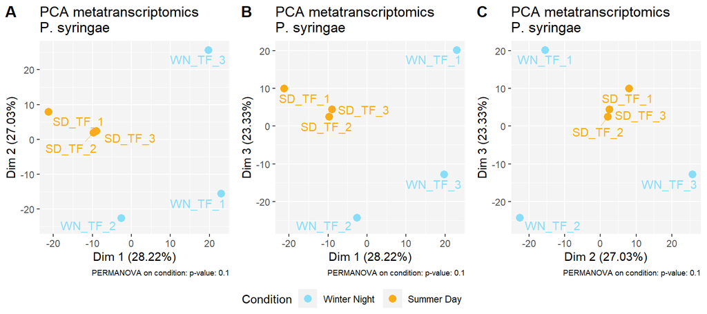

```r
pca_tmp <- rbind(res_pca$ind$coord,
                 res_pca$ind.sup$coord) %>% data.frame() %>%
  rownames_to_column("sample")


pca_data <- left_join(pca_tmp, rownames_to_column(metadata_table), by=join_by("sample" == "rowname"))
rm(pca_tmp)

D1_text = paste0("Dim 1 (",
                 round(data.frame(res_pca$eig)$percentage.of.variance[1], digits=2),
                 "%)")
D2_text = paste0("Dim 2 (",
                 round(data.frame(res_pca$eig)$percentage.of.variance[2], digits=2),
                 "%)")
D3_text = paste0("Dim 3 (",
                 round(data.frame(res_pca$eig)$percentage.of.variance[3], digits=2),
                 "%)")

ggplot(pca_data) +
  geom_point(aes(x=Dim.1, y=Dim.2, colour=color, ), size=3) +
  scale_colour_identity("Condition", labels=c("Winter Night", "Summer Day"), guide = "legend") +
  ggrepel::geom_text_repel(aes(x=Dim.1, y=Dim.2, colour=color, label=sample),
                           nudge_y = -2,  seed = 42, segment.size=0.1, show.legend = FALSE) +
  xlab(D1_text) +
  ylab(D2_text) +
  ggtitle("PCA metatranscriptomics  \nP. syringae") +
  labs(caption =  paste0("PERMANOVA on condition: p-value: ", pv)) +
  theme(panel.background= element_rect(fill="#f4f4f4"),
        plot.caption = element_text(size=7)) -> p1


ggplot(pca_data) +
  geom_point(aes(x=Dim.1, y=Dim.3, colour=color), size=3) +
  scale_colour_identity("Condition", labels=c("Winter Night", "Summer Day"), guide = "legend") +
  ggrepel::geom_text_repel(aes(x=Dim.1, y=Dim.3, colour=color, label=sample),
                           nudge_y = -2,  seed = 42, segment.size=0.1, show.legend = FALSE) +
  xlab(D1_text) +
  ylab(D3_text) +
  ggtitle("PCA metatranscriptomics  \nP. syringae") +
  labs(caption =  paste0("PERMANOVA on condition: p-value: ", pv)) +
  theme(panel.background= element_rect(fill="#f4f4f4"),
        plot.caption = element_text(size=7)) -> p2

ggplot(pca_data) +
  geom_point(aes(x=Dim.2, y=Dim.3, colour=color), size=3) +
  scale_colour_identity("Condition", labels=c("Winter Night", "Summer Day"), guide = "legend") +
  ggrepel::geom_text_repel(aes(x=Dim.2, y=Dim.3, colour=color, label=sample),
                           nudge_y = -2,  seed = 42, segment.size=0.1, show.legend = FALSE) +
  xlab(D2_text) +
  ylab(D3_text) +
  ggtitle("PCA metatranscriptomics  \nP. syringae") +
  labs(caption =  paste0("PERMANOVA on condition: p-value: ", pv)) +
  theme(panel.background= element_rect(fill="#f4f4f4"),
        plot.caption = element_text(size=7)) -> p3

plotgrid_PCA <- ggarrange(p1, p2, p3, labels = c("A", "B", "C"), common.legend=TRUE, legend="bottom", nrow=1)

print(plotgrid_PCA)
```

```r
ggsave(plot = plotgrid_PCA, filename = "../figures/PCA_metatranscriptomics_3_composantes_psesy.tiff", dpi = 300, width = 15, height = 5, bg="white")

ggsave(plot=p1, filename = "../figures/PCA_metatranscriptomics_psesy.tiff", dpi = 300, width = 6, height = 5, bg="white")
```

```r
row_coord <- res_pca$ind$coord

invisible(rgl::open3d())

#rgl::bg3d("lightgray")
rgl::plot3d(x=row_coord[c("WN_TF_1", "WN_TF_2", "WN_TF_3"), 1],
            y=row_coord[c("WN_TF_1", "WN_TF_2", "WN_TF_3"), 2],
            z=row_coord[c("WN_TF_1", "WN_TF_2", "WN_TF_3"), 3],
            xlab = paste0(colnames(row_coord)[1] , " (" , substr(as.character(res_pca$eig[,2][1]), 1, 5) , "%)"),
            ylab = paste0(colnames(row_coord)[2] , " (" , substr(as.character(res_pca$eig[,2][2]), 1, 5) , "%)"),
            zlab = paste0(colnames(row_coord)[3] , " (" , substr(as.character(res_pca$eig[,2][3]), 1, 5) , "%)"),
            xlim = c(min(row_coord[, 1]), max(row_coord[, 1])+10),
            ylim = c(min(row_coord[, 2]), max(row_coord[, 2])+10),
            zlim = c(min(row_coord[, 3]), max(row_coord[, 3])+10),
            col = "darkcyan",
            size=10,
            main = "PCA P. syringae")

rgl::text3d(x=row_coord[c("WN_TF_1", "WN_TF_2", "WN_TF_3"), 1]+3,
            y=row_coord[c("WN_TF_1", "WN_TF_2", "WN_TF_3"), 2]+3,
            z=row_coord[c("WN_TF_1", "WN_TF_2", "WN_TF_3"), 3]+3,
            text=c("WN_TF_1", "WN_TF_2", "WN_TF_3"),
            col = "darkcyan",
            size=10)


rgl::points3d(x=row_coord[c("SD_TF_1", "SD_TF_2", "SD_TF_3"), 1],
              y=row_coord[c("SD_TF_1", "SD_TF_2", "SD_TF_3"), 2],
              z=row_coord[c("SD_TF_1", "SD_TF_2", "SD_TF_3"), 3],
              col = "darkorange",
              size=10)

rgl::text3d(x=row_coord[c("SD_TF_1", "SD_TF_2", "SD_TF_3"), 1]+3,
            y=row_coord[c("SD_TF_1", "SD_TF_2", "SD_TF_3"), 2]+3,
            z=row_coord[c("SD_TF_1", "SD_TF_2", "SD_TF_3"), 3]+3,
            text=c("SD_TF_1", "SD_TF_2", "SD_TF_3"),
            col = "darkorange",
            size=10)


## Activate for or gif generation
#par3d(windowRect = c(20, 30, 800, 800))

#rgl::movie3d(
#  movie="3DAnimated_PCA_psesy",
#  spin3d( axis = c(0, 0, 1), rpm = 3),
#  duration = 20,
#  dir = "../figures",
#  type = "gif",
#  clean = TRUE, webshot=FALSE, fps=10)
```

[interactive chart not shown]

#### *Rhodococcus enclensis*

```r
res_pca <- PCA(t(rhoen_clr), scale.unit = TRUE, graph = FALSE)
```

```r
counts_data <- t(rhoen_clr)
metadata_tmp <- data.frame(metadata_table, stringsAsFactors = TRUE)
permanova <- adonis2(formula = as.formula(paste0("counts_data~", "condition")),
                     data = metadata_tmp, method="euclidean", # method="bray", #otu_data~TIME
                     permutations = 999, sqrt.dist = FALSE, add = FALSE, by = "terms")
pv = permanova$`Pr(>F)`[1]
# print(pv)

rm(counts_data, metadata_tmp)
```

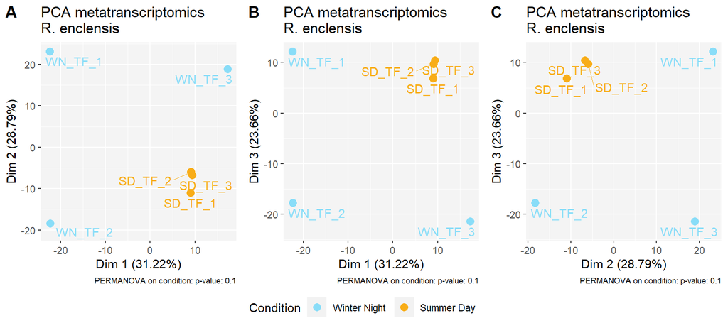

```r
pca_tmp <- rbind(res_pca$ind$coord,
                 res_pca$ind.sup$coord) %>% data.frame() %>%
  rownames_to_column("sample")


pca_data <- left_join(pca_tmp, rownames_to_column(metadata_table), by=join_by("sample" == "rowname"))
rm(pca_tmp)

D1_text = paste0("Dim 1 (",
                 round(data.frame(res_pca$eig)$percentage.of.variance[1], digits=2),
                 "%)")
D2_text = paste0("Dim 2 (",
                 round(data.frame(res_pca$eig)$percentage.of.variance[2], digits=2),
                 "%)")
D3_text = paste0("Dim 3 (",
                 round(data.frame(res_pca$eig)$percentage.of.variance[3], digits=2),
                 "%)")

ggplot(pca_data) +
  geom_point(aes(x=Dim.1, y=Dim.2, colour=color, ), size=3) +
  scale_colour_identity("Condition", labels=c("Winter Night", "Summer Day"), guide = "legend") +
  ggrepel::geom_text_repel(aes(x=Dim.1, y=Dim.2, colour=color, label=sample),
                           nudge_y = -2,  seed = 42, segment.size=0.1, show.legend = FALSE) +
  xlab(D1_text) +
  ylab(D2_text) +
  ggtitle("PCA metatranscriptomics  \nR. enclensis") +
  labs(caption =  paste0("PERMANOVA on condition: p-value: ", pv)) +
  theme(panel.background= element_rect(fill="#f4f4f4"),
        plot.caption = element_text(size=7)) -> p1


ggplot(pca_data) +
  geom_point(aes(x=Dim.1, y=Dim.3, colour=color), size=3) +
  scale_colour_identity("Condition", labels=c("Winter Night", "Summer Day"), guide = "legend") +
  ggrepel::geom_text_repel(aes(x=Dim.1, y=Dim.3, colour=color, label=sample),
                           nudge_y = -2,  seed = 42, segment.size=0.1, show.legend = FALSE) +
  xlab(D1_text) +
  ylab(D3_text) +
  ggtitle("PCA metatranscriptomics  \nR. enclensis") +
  labs(caption =  paste0("PERMANOVA on condition: p-value: ", pv)) +
  theme(panel.background= element_rect(fill="#f4f4f4"),
        plot.caption = element_text(size=7)) -> p2

ggplot(pca_data) +
  geom_point(aes(x=Dim.2, y=Dim.3, colour=color), size=3) +
  scale_colour_identity("Condition", labels=c("Winter Night", "Summer Day"), guide = "legend") +
  ggrepel::geom_text_repel(aes(x=Dim.2, y=Dim.3, colour=color, label=sample),
                           nudge_y = -2,  seed = 42, segment.size=0.1, show.legend = FALSE) +
  xlab(D2_text) +
  ylab(D3_text) +
  ggtitle("PCA metatranscriptomics  \nR. enclensis") +
  labs(caption =  paste0("PERMANOVA on condition: p-value: ", pv)) +
  theme(panel.background= element_rect(fill="#f4f4f4"),
        plot.caption = element_text(size=7)) -> p3

plotgrid_PCA <- ggarrange(p1, p2, p3, labels = c("A", "B", "C"), common.legend=TRUE, legend="bottom", nrow=1)

print(plotgrid_PCA)
```

```r
ggsave(plot = plotgrid_PCA, filename = "../figures/PCA_metatranscriptomics_3_composantes_rhoen.tiff", dpi = 300, width = 15, height = 5, bg="white")

ggsave(plot=p1, filename = "../figures/PCA_metatranscriptomics_rhoen.tiff", dpi = 300, width = 6, height = 5, bg="white")
```

```r
row_coord <- res_pca$ind$coord

invisible(rgl::open3d())

#rgl::bg3d("lightgray")
rgl::plot3d(x=row_coord[c("WN_TF_1", "WN_TF_2", "WN_TF_3"), 1],
            y=row_coord[c("WN_TF_1", "WN_TF_2", "WN_TF_3"), 2],
            z=row_coord[c("WN_TF_1", "WN_TF_2", "WN_TF_3"), 3],
            xlab = paste0(colnames(row_coord)[1] , " (" , substr(as.character(res_pca$eig[,2][1]), 1, 5) , "%)"),
            ylab = paste0(colnames(row_coord)[2] , " (" , substr(as.character(res_pca$eig[,2][2]), 1, 5) , "%)"),
            zlab = paste0(colnames(row_coord)[3] , " (" , substr(as.character(res_pca$eig[,2][3]), 1, 5) , "%)"),
            xlim = c(min(row_coord[, 1]), max(row_coord[, 1])+10),
            ylim = c(min(row_coord[, 2]), max(row_coord[, 2])+10),
            zlim = c(min(row_coord[, 3]), max(row_coord[, 3])+10),
            col = "darkcyan",
            size=10,
            main = "PCA R. enclensis")

rgl::text3d(x=row_coord[c("WN_TF_1", "WN_TF_2", "WN_TF_3"), 1]+3,
            y=row_coord[c("WN_TF_1", "WN_TF_2", "WN_TF_3"), 2]+3,
            z=row_coord[c("WN_TF_1", "WN_TF_2", "WN_TF_3"), 3]+3,
            text=c("WN_TF_1", "WN_TF_2", "WN_TF_3"),
            col = "darkcyan",
            size=10)


rgl::points3d(x=row_coord[c("SD_TF_1", "SD_TF_2", "SD_TF_3"), 1],
              y=row_coord[c("SD_TF_1", "SD_TF_2", "SD_TF_3"), 2],
              z=row_coord[c("SD_TF_1", "SD_TF_2", "SD_TF_3"), 3],
              col = "darkorange",
              size=10)

rgl::text3d(x=row_coord[c("SD_TF_1", "SD_TF_2", "SD_TF_3"), 1]+3,
            y=row_coord[c("SD_TF_1", "SD_TF_2", "SD_TF_3"), 2]+3,
            z=row_coord[c("SD_TF_1", "SD_TF_2", "SD_TF_3"), 3]+3,
            text=c("SD_TF_1", "SD_TF_2", "SD_TF_3"),
            col = "darkorange",
            size=10)


## Activate for or gif generation
#par3d(windowRect = c(20, 30, 800, 800))

#rgl::movie3d(
#  movie="3DAnimated_PCA_rhoen",
#  spin3d( axis = c(0, 0, 1), rpm = 3),
#  duration = 20,
#  dir = "../figures",
#  type = "gif",
#  clean = TRUE, webshot=FALSE, fps=10)
```

[interactive chart not shown]

### Samples hierarchical clustering by species

#### *Dioszegia hungarica*

```r
#### Sample distances ####
message("Computing inter-sample distances")

## Pearson
dist_pearson_diohu <- as.dist(1 - cor(diohu_clr, use = "everything",
                                method = "pearson"))
```

```r
message("Sample clustering")

tree_pearson_diohu <- hclust(dist_pearson_diohu, method = "complete")
```

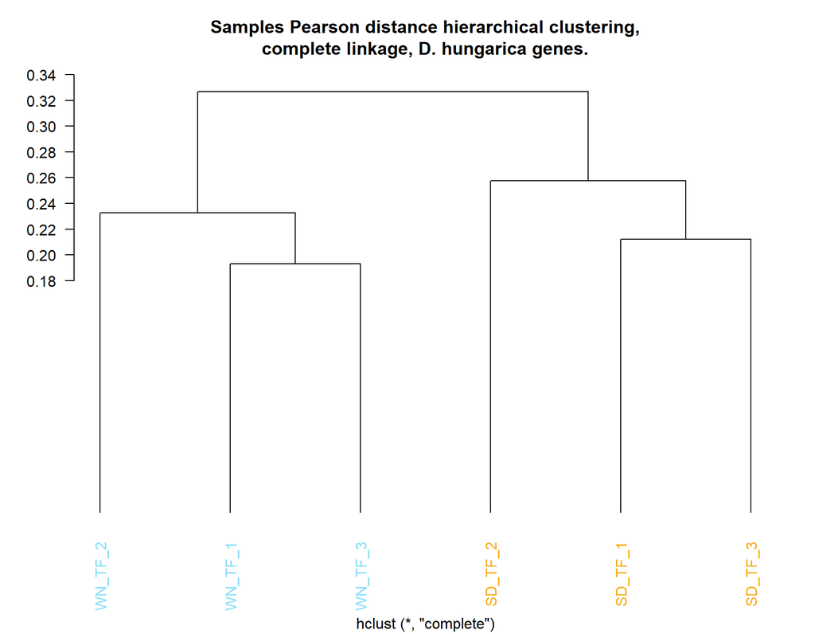

```r
par(bg = "white", mfrow=c(1, 1))
plotColoredClusters(tree_pearson_diohu, labs = row.names(metadata_table),
                    ylab = NA, xlab = NA, cex = 1, las = 1,
                    cols = metadata_table$color, col = "black",
                    main = "Samples Pearson distance hierarchical clustering,
complete linkage, D. hungarica genes.")
```

Natural separation of samples according to their incubation condition for *D. hungarica*.

#### *Pseudomonas graminis*

```r
#### Sample distances ####
message("Computing inter-sample distances")

## Pearson
dist_pearson_psegr <- as.dist(1 - cor(psegr_clr, use = "everything",
                                method = "pearson"))
```

```r
message("Sample clustering")

tree_pearson_psegr <- hclust(dist_pearson_psegr, method = "complete")
```

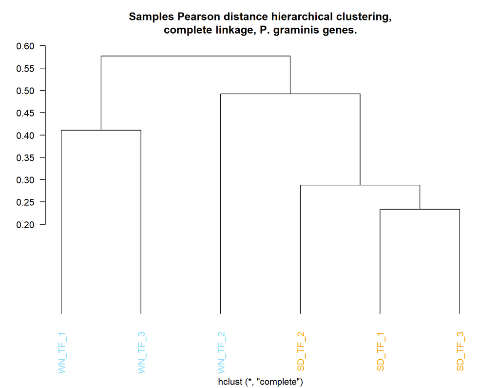

```r
par(bg = "white", mfrow=c(1, 1))
plotColoredClusters(tree_pearson_psegr, labs = row.names(metadata_table),
                    ylab = NA, xlab = NA, cex = 1, las = 1,
                    cols = metadata_table$color, col = "black",
                    main = "Samples Pearson distance hierarchical clustering,
complete linkage, P. graminis genes.")
```

For *P. graminis*, the clustering does not distinguish between the two incubation conditions, probably because of the very low amounts of counts attributed to this species.

#### *Pseudomonas syringae*

```r
#### Sample distances ####
message("Computing inter-sample distances")

## Pearson
dist_pearson_psesy <- as.dist(1 - cor(psesy_clr, use = "everything",
                                method = "pearson"))
```

```r
message("Sample clustering")

tree_pearson_psesy <- hclust(dist_pearson_psesy, method = "complete")
```

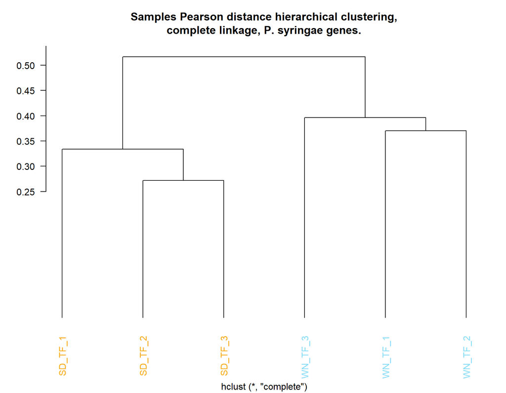

```r
par(bg = "white", mfrow=c(1, 1))
plotColoredClusters(tree_pearson_psesy, labs = row.names(metadata_table),
                    ylab = NA, xlab = NA, cex = 1, las = 1,
                    cols = metadata_table$color, col = "black",
                    main = "Samples Pearson distance hierarchical clustering,
complete linkage, P. syringae genes.")
```

Samples are separated according to their experimental condition, which is encouraging for further analysis of *P. syringae*.

#### *Rhodococcus enclensis*

```r
#### Sample distances ####
message("Computing inter-sample distances")

## Pearson
dist_pearson_rhoen <- as.dist(1 - cor(rhoen_clr, use = "everything",
                                method = "pearson"))
```

```r
message("Sample clustering")

tree_pearson_rhoen <- hclust(dist_pearson_rhoen, method = "complete")
```

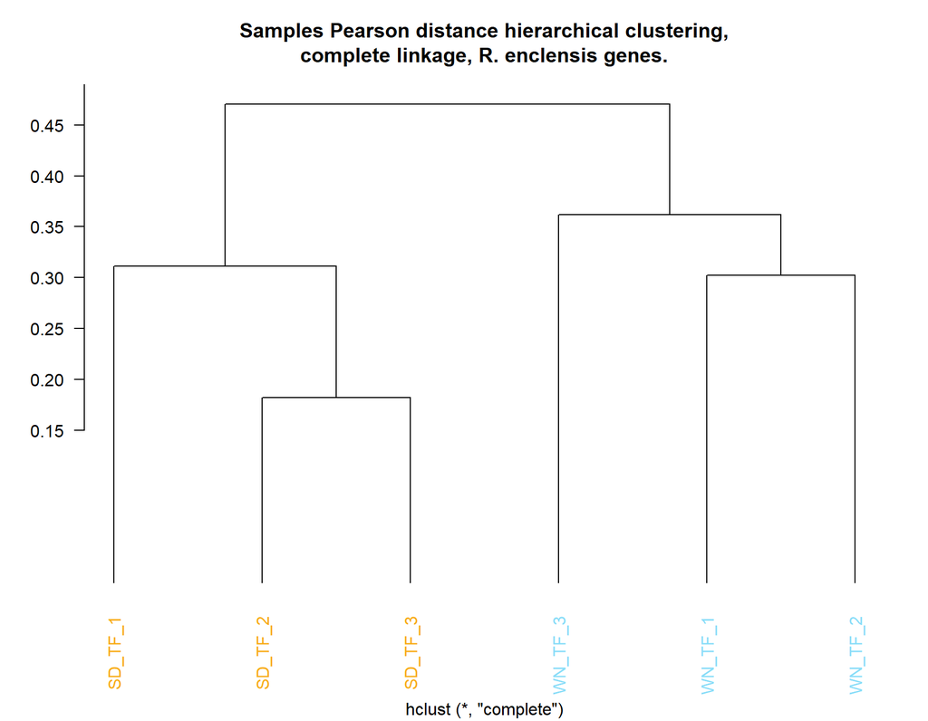

```r
par(bg = "white", mfrow=c(1, 1))
plotColoredClusters(tree_pearson_rhoen, labs = row.names(metadata_table),
                    ylab = NA, xlab = NA, cex = 1, las = 1,
                    cols = metadata_table$color, col = "black",
                    main = "Samples Pearson distance hierarchical clustering,
complete linkage, R. enclensis genes.")
```

Again, samples are naturally separated according to their incubation condition for *R. enclensis*.

## Differential analyses with MTXmodel (whole assemblage metatranscriptomics data)

MTXmodel was used on the complete assemblage at once. As input, filtered data (without the undetected genes) but untransformed was given to MTXmodel, as it performs its own CLR normalisation.

`analysis_method = 'LM'`

`correction = 'BH'`,

```r
fit_data <- MTXmodel(
    counts_standard, metadata_table, 'MTXmodel_output',
    cores = 2,
    fixed_effects = c('temperature'),
    reference = c("temperature,5"),
    min_abundance = 0,
    min_prevalence = 0,
    normalization = 'CLR',
    analysis_method = 'LM',
    correction = 'BH',
    standardize = FALSE,
    transform = 'NONE',
    plot_scatter = FALSE,
    plot_heatmap = TRUE)
```

```r
# Loading MTXmodel results
res_mtx <- read.csv("../scripts/MTXmodel_output/all_results.tsv", sep="\t", row.names="feature")


tryCatch({
  inner_join(rownames_to_column(res_mtx), annotation_table_fig, by=c("rowname" = "gene")) -> res_mtx_fig
  res_mtx_fig %>% filter(abs(qval) <= 0.2) -> res_mtx_fig
  },
  error=function(e){str(e)
  }
)


## Data for final table
annotation_table_long <- read.csv("../data/annotations_final_community_long2.tsv", sep="\t", row.names = "Geneid")

tryCatch({
  annotation_table_long$gene <- row.names(annotation_table_long)
  inner_join(rownames_to_column(res_mtx), annotation_table_long, by=c("rowname" = "gene")) -> res_mtx_filt
  res_mtx_filt %>% filter(abs(qval) <= 0.2) -> res_mtx_filt
  },
  error=function(e){str(e)
  }
)
```

## Differential analyses with DESeq2 (metatranscriptomics data species by species)

As a complementary approach, separate differential analyses were conducted for each species separately with DESeq2.

### DESeq2 analyses preparation

```r
metadata_table$temperature <- factor(metadata_table$temperature)
```

We use filtered counts data (only genes detected in at least 70% of biological samples). Zeroes are conserved as is. We round the counts matrix before performing DESeq2 analysis.

```r
diohu_df <- counts_filtered[diohu_geneid,]
psegr_df <- counts_filtered[psegr_geneid,]
psesy_df <- counts_filtered[psesy_geneid,]
rhoen_df <- counts_filtered[rhoen_geneid,]
```

```r
res_df <- data.frame(gene=character(),
                     baseMean=numeric(),
                     log2FoldChange=numeric(),
                     lfcSE=numeric(),
                     stat=numeric(),
                     pvalue=numeric(),
                     padj=numeric(),
                     condition=factor(),
                     SAMPLE_COMPARISON=factor(),
                     organism=factor())
```

### *Dioszegia hungarica*

```r
compute_deseq2_analysis(diohu_df,
                        metadata_table,
                        #subset_var = "temperature",
                        #select = "3.5",
                        contrast_col="temperature",
                        ref="5",
                        tested="17") -> res

tryCatch({res$organism <- "D. hungarica"},
  error=function(e){str(e) # prints structure of exception
  })

res_df <- rbind(res_df, res)
```

### *Rhodococcus enclensis*

```r
compute_deseq2_analysis(rhoen_df,
                        metadata_table,
                        #subset_var = "temperature",
                        #select = "3.5",
                        contrast_col="temperature",
                        ref="5",
                        tested="17") -> res

tryCatch({res$organism <- "R. enclensis"},
  error=function(e){str(e)
  })

res_df <- rbind(res_df, res)
```

### *Pseudomonas syringae*

```r
compute_deseq2_analysis(psesy_df,
                        metadata_table,
                        #subset_var = "temperature",
                        #select = "3.5",
                        contrast_col="temperature",
                        ref="5",
                        tested="17") -> res

tryCatch({res$organism <- "P. syringae"},
  error=function(e){str(e)
  })

res_df <- rbind(res_df, res)
```

### *Pseudomonas graminis*

```r
compute_deseq2_analysis(psegr_df,
                        metadata_table,
                        #subset_var = "temperature",
                        #select = "3.5",
                        contrast_col="temperature",
                        ref="5",
                        tested="17") -> res

tryCatch({res$organism <- "P. graminis"},
  error=function(e){str(e)
  })

res_df <- rbind(res_df, res)
```

### Filter DESeq2 data

```r
tryCatch({
  res_df %>% inner_join(annotation_table_fig, by="gene") -> tmp_res_df
  tmp_res_df %>% filter(padj <= 0.2) -> res_deseq_fig
  },
  error=function(e){str(e)
  }
)

rm(tmp_res_df)

## data for final table
annotation_table_long <- read.csv("../data/annotations_final_community_long2.tsv", sep="\t", row.names = "Geneid")

tryCatch({
  annotation_table_long$gene <- row.names(annotation_table_long)
  res_df %>% inner_join(annotation_table_long, by="gene") -> res_df
  res_df %>% filter(padj <= 0.2) -> res_deseq_filt # & abs(log2FoldChange) >= 1
  },
  error=function(e){str(e)
  }
)
```

### Save differentially expressed genes (DEGs) all methods

```r
temp_df <- right_join(rownames_to_column(res_mtx), annotation_table_long, join_by("rowname"=="gene"))
rename(temp_df, "gene" = "rowname") -> temp_df



all_genes <- full_join(res_df, temp_df,  by=c("gene", "locus_tag", "transcriptId", "Organism",
                                              "Chr", "Start", "End", "Strand", "Length",
                                              "product", "COG_process", "COG_category",
                                              "COGid", "GOs", "COG_cat", "COG_category_long",
                                              "ecNum" ),
                       suffix = c("", "w"))

rm(temp_df)
columns_to_remove <- grep(".w", names(all_genes))
all_genes %>% dplyr::select(-columns_to_remove) %>% filter(qval<=0.2 | padj<=0.2 ) -> all_genes_filtered

write.table(all_genes_filtered, "../results/DEG_all_methods_community.tsv", sep='\t', row.names = FALSE)

write.table(res_df, "../results/DEG_DESeq2_all_community.tsv", sep='\t', row.names = FALSE)
sign_deseq2_df <- res_df
```

## Plot transcript expression coefficient (SD vs WN)

```r
#### Both methods DEGs



full_join(all_genes_filtered, annotation_table_fig, by="gene") -> data


data$title <- "Differentially expressed genes SD vs WN by strain (DESeq2 & MTXmodel)"
data$Organism <- factor(data$organism, levels=c("D. hungarica", "P. graminis", "P. syringae", "R. enclensis"))




custom_strips <- strip_nested(background_x = elem_list_rect(fill = c("lightgrey",
                                                                     species_colours[["D.hungarica"]],
                                                                     species_colours[["P.syringae"]],
                                                                     species_colours[["R.enclensis"]])),
                              text_x = list(element_text(face = "plain", colour = "black", size = 17),
                                            element_text(face = "italic", colour = "white", size = 15),
                                            element_text(face = "italic", colour = "white", size = 15),
                                            element_text(face = "italic", colour = "white", size = 15)),
                              by_layer_x = FALSE)


ggplot(data, aes(x = coef, y = COG_category.y,  color = after_scale(alpha(fill, 0.3)), fill=COG_category_long.y, alpha=0.7, label=name_figure)) +
  geom_point(aes(alpha=0.7), position="dodge") +
  geom_violin(aes(alpha=0.3), show.legend = TRUE) +
  annotate("rect", xmin=-Inf, xmax=0, ymin=-Inf, ymax=Inf, fill="#184ca5", alpha=0.1) +
  annotate("rect", xmin=0, xmax=Inf, ymin=-Inf, ymax=Inf, fill="gold", alpha=0.1) +
  geom_vline(xintercept = 0, linetype="dashed") +
  ylab("COG category") +
  xlab("MTXmodel coefficient") +
  ggrepel::geom_text_repel(nudge_y = 0.5, segment.size=0.1, seed = 42) +
  guides(fill=guide_legend(ncol=4), alpha="none", color="none") + #color="none",
  scale_y_discrete(limits=rev(names(vect_COG_category_long))) +
  scale_colour_manual(limits=vect_COG_category_long, values=COG_colours, drop=FALSE) +
  scale_fill_manual(limits=vect_COG_category_long, values=COG_colours, drop=FALSE) +
  theme(axis.title = element_text(size=13, "Differentially expressed genes SD vs WN"),
        axis.text = element_text(size=13),
        strip.text.y = element_text(size = 17),
        #strip.text.x = element_text(size = 17, face = "italic"),
        legend.text = element_text(size = 12),
        legend.title = element_blank(),
        legend.key.size = unit(0.5, "line"),
        legend.position = "bottom",
        panel.background = element_rect(fill = "#f4f4f4")) +
  facet_nested(~title + Organism, strip = custom_strips, drop=TRUE) -> plot_degs

# print(plot_degs)
#
# ggsave(plot = plot_degs, filename = "../figures/DEG_day_vs_night_commu_both_methods_vertical.tiff", dpi = 300, width = 13, height = 13, bg="white")
```

```r
columns_to_remove <- grep(".w", names(all_genes))
all_genes %>% dplyr::select(-columns_to_remove) %>% filter(!is.na(coef)) -> all_genes_unfiltered

full_join(all_genes_unfiltered, annotation_table_long, by="gene") %>% filter(!is.na(coef)) -> data
data[data$COG_category_long.y == "S: Function Unknown", "COG_category_long.y"] <- "S: Function unknown"
data$title <- "All detected genes"
data$subtitle <- "Assemblage"
data$Organism <- factor(data$organism, levels=c("D. hungarica", "P. graminis", "P. syringae", "R. enclensis"))
data$COG_category_fig <- substr(data$COG_category_long.y, 0, 1)


custom_strips <- strip_nested(background_x = elem_list_rect(fill = c("lightgrey", "black")),
                              text_x = list(element_text(face = "plain", colour = "black", size = 17),
                                            element_text(face = "italic", colour = "white", size = 15)),
                              by_layer_x = FALSE)

custom_strips_strains <- strip_nested(background_x = elem_list_rect(fill = c("lightgrey",
                                                                     species_colours[["D.hungarica"]],
                                                                     species_colours[["P.syringae"]],
                                                                     species_colours[["R.enclensis"]])),
                              text_x = list(element_text(face = "plain", colour = "black", size = 17),
                                            element_text(face = "italic", colour = "white", size = 15),
                                            element_text(face = "italic", colour = "white", size = 15),
                                            element_text(face = "italic", colour = "white", size = 15)),
                              by_layer_x = FALSE)

ggplot(data, aes(x = coef, y = COG_category_fig,color = after_scale(alpha(fill, 0.3)), fill=COG_category_long.y, alpha=0.9)) + #label=name_figure
  # geom_point(aes(alpha=0.7)) + #, position="dodge"
  geom_violin(aes(alpha=0.3), show.legend = TRUE) +
  geom_boxplot(outlier.colour = "black", width=0.2, color="white", outlier.alpha = 0.4, alpha=0.2, show.legend = FALSE) +
  annotate("rect", xmin=-Inf, xmax=0, ymin=-Inf, ymax=Inf, fill="#184ca5", alpha=0.1) +
  annotate("rect", xmin=0, xmax=Inf, ymin=-Inf, ymax=Inf, fill="gold", alpha=0.1) +
  geom_vline(xintercept = 0, linetype="dashed") +
  ylab("COG category") +
  xlab("MTXmodel coefficient") +
  # ggrepel::geom_text_repel(nudge_y = 0.5, segment.size=0.1, seed = 42) +
  guides(fill=guide_legend(ncol=4), alpha="none", color="none") + #color="none",
  scale_y_discrete(limits=rev(names(vect_COG_category_long))) +
  scale_colour_manual(limits=vect_COG_category_long, values=COG_colours, drop=FALSE) +
  scale_fill_manual(limits=vect_COG_category_long, values=COG_colours, drop=FALSE) +
  theme(axis.title = element_text(size=13, "Expression coefficient (in SD vs WN) of all assemblage detected genes"),
        axis.text = element_text(size=13),
        strip.text.y = element_text(size = 17),
        #strip.text.x = element_text(size = 17, face = "italic"),
        legend.text = element_text(size = 12),
        legend.title = element_blank(),
        legend.key.size = unit(0.5, "line"),
        legend.position = "bottom",
        panel.background = element_rect(fill = "#f4f4f4")) -> p

  p + facet_nested(~title + subtitle, strip = custom_strips, drop=TRUE) -> plot_assemblage
  p + facet_nested(~title + Organism, strip = custom_strips_strains, drop=TRUE) +
    guides(fill=guide_legend(ncol=3), alpha="none", color="none") +
    theme(legend.text = element_text(size = 10))-> plot_strains

# print(plot_assemblage)
#
ggsave(plot = plot_assemblage, filename = "../figures/expressed_genes_MTX_coeff_assemblage.tiff", dpi = 300, width = 13/3, height = 13, bg="white")

ggsave(plot = plot_strains, filename = "../figures/expressed_genes_MTX_coeff_strains.tiff", dpi = 300, width = 13, height = 13, bg="white")
```

```r
plot_all <- ggarrange(plot_assemblage, plot_degs,
                      labels = c("A", "B"),
                      common.legend=TRUE,
                      legend="bottom",
                      nrow=1,
                      widths = c(1, 3))

print(plot_all)
```

[figure not shown]

```r
ggsave(plot = plot_all, filename = "../figures/Figure_4.tiff", dpi = 300, width = 13+4.35, height = 13, bg="white")

print(plot_strains)
```

[figure not shown]